# Insula laterality (INS_HE merged v1+v2)

Full v2 pipeline on corrected INS table — same notebook as laterality_ver2.Rmd, standalone

2026-04-27

This is the **full** laterality analysis in one file (no child document). It matches **`laterality_ver2.Rmd`**: SQ1–SQ6 structure from **`laterality_by_questions.Rmd`**, plus adjusted PERMANOVA, balanced Monte Carlo PERMANOVA, and `lm(log1p(total) ~ Neuron_Type + Soma_Side)`.

**Default input** is the corrected workbook **`251637_INS_HE_inferred.xlsx`**. Edit **`PATH_INS_XLSX`** in `config` if you use `251637_INS_HE.xlsx` or `251637_INS.xlsx` instead.

**Prelude (table changes in inferred INS_HE):** verified soma locations; rule-based fill for previously unknown side/type; some PrCO neurons reclassified into insular groups; `Soma_Region` uses `CL_`/`CR_` stripped in prep with side in **`Soma_Side`**.

**Maintenance:** Body matches **`laterality_ver2.Rmd`** as of the last copy. If you change v2 logic, update this file the same way (or copy `laterality_ver2.Rmd` over this file and re-apply the header + `config` chunk above).

```r
# --- Paths (relative to this Rmd: R_analysis/scripts/) ---
PATH_INS_XLSX   <- "../../neuron_tables_new/251637_INS_HE_inferred.xlsx"
PATH_CLUSTER_RDS <- "data_output/clustering/clustering_results.rds"
PATH_FNT_XLSX    <- "data_output/clustering/raw_matrix_神经元矩阵.xlsx"
LR_ANALYSIS_DIR  <- "LR_analysis"
FIGURE_DIR       <- file.path(LR_ANALYSIS_DIR, "figures")
STATS_DIR        <- file.path(LR_ANALYSIS_DIR, "stats")
TABLE_DIR        <- file.path(LR_ANALYSIS_DIR, "tables")
REPORT_DIR       <- file.path(LR_ANALYSIS_DIR, "reports")
stopifnot(file.exists(PATH_INS_XLSX))
dir.create(LR_ANALYSIS_DIR, recursive = TRUE, showWarnings = FALSE)
dir.create(FIGURE_DIR, recursive = TRUE, showWarnings = FALSE)
dir.create(STATS_DIR, recursive = TRUE, showWarnings = FALSE)
dir.create(TABLE_DIR, recursive = TRUE, showWarnings = FALSE)
dir.create(REPORT_DIR, recursive = TRUE, showWarnings = FALSE)

PERM_N <- 999L
BALANCE_REPS           <- 299L
BALANCE_MIN_PER_SIDE   <- 3L
RUN_BALANCE_PERMANOVA  <- TRUE
RUN_BALANCE_BRAY_PROP  <- FALSE
EXPORT_XLSX            <- TRUE
EXPORT_FLAT_FILES      <- FALSE
WRITE_REPORT_IMMEDIATELY <- TRUE

set.seed(42)
```

# Preparation: align projection matrices with neuron metadata

```r
cluster_info <- readRDS(PATH_CLUSTER_RDS)
proj_ipsi    <- read_excel(PATH_INS_XLSX, sheet = "Projection_Strength_L3_ipsi")
proj_contra  <- read_excel(PATH_INS_XLSX, sheet = "Projection_Strength_L3_contra")
summary_sh   <- read_excel(PATH_INS_XLSX, sheet = "Summary")

# Normalize region labels to hemisphere-neutral form.
# Handles prefixes like CL_/CR_, L_/R_, L-/R-; side remains in Soma_Side.
.strip_soma_region_prefix <- function(x) {
  v <- trimws(as.character(x))
  w <- sub("^(CL|CR)[_\\-]", "", v, perl = TRUE)
  w <- sub("^[LR][_\\-]", "", w, perl = TRUE)
  ifelse(nzchar(w), w, v)
}

.pick_first_col <- function(df, candidates) {
  hit <- candidates[candidates %in% colnames(df)][1]
  if (is.na(hit)) NA_character_ else hit
}

.ap_col_meta <- .pick_first_col(summary_sh, c(
  "Soma_NII_Y", "Soma_Phys_Y",
  "AP", "ap", "Soma_AP", "soma_ap", "Y", "y", "Soma_Y", "soma_y"
))
.ml_col_meta <- .pick_first_col(summary_sh, c(
  "Soma_NII_X", "Soma_Phys_X",
  "ML", "ml", "Soma_ML", "soma_ml", "X", "x", "Soma_X", "soma_x"
))

summary_coords <- summary_sh %>%
  dplyr::select(NeuronID, everything()) %>%
  transmute(
    NeuronID = NeuronID,
    AP_coord = if (!is.na(.ap_col_meta)) as.numeric(.data[[.ap_col_meta]]) else NA_real_,
    ML_coord = if (!is.na(.ml_col_meta)) as.numeric(.data[[.ml_col_meta]]) else NA_real_
  )

meta_cols <- 6L

proj_ipsi <- proj_ipsi %>%
  merge(cluster_info$cluster_df %>% dplyr::select(-BioType), by = "NeuronID") %>%
  merge(summary_sh %>% dplyr::select(NeuronID, Soma_Region, Soma_Side), by = "NeuronID") %>%
  relocate(NeuronID, Soma_Region, Soma_Side, Neuron_Type, Cluster, DendroOrder) %>%
  mutate(Soma_Region = factor(.strip_soma_region_prefix(Soma_Region)))

proj_contra <- proj_contra %>%
  merge(cluster_info$cluster_df %>% dplyr::select(-BioType), by = "NeuronID") %>%
  merge(summary_sh %>% dplyr::select(NeuronID, Soma_Region, Soma_Side), by = "NeuronID") %>%
  relocate(NeuronID, Soma_Region, Soma_Side, Neuron_Type, Cluster, DendroOrder) %>%
  mutate(Soma_Region = factor(.strip_soma_region_prefix(Soma_Region)))

mat_ipsi <- t(as.matrix(proj_ipsi %>% dplyr::select(-(1:meta_cols))))
colnames(mat_ipsi) <- proj_ipsi$NeuronID

mat_contra <- t(as.matrix(proj_contra %>% dplyr::select(-(1:meta_cols))))
colnames(mat_contra) <- proj_contra$NeuronID

stopifnot(all.equal(proj_ipsi$NeuronID, proj_contra$NeuronID))

meta <- proj_ipsi %>%
  transmute(
    NeuronID = NeuronID,
    Soma_Region = droplevels(Soma_Region),
    Soma_Side = factor(Soma_Side, levels = c("L", "R")),
    Neuron_Type = factor(Neuron_Type),
    Cluster = Cluster
  ) %>%
  left_join(summary_coords, by = "NeuronID")

cat(sprintf("Neurons: n=%d | L=%d R=%d\n",
            nrow(meta), sum(meta$Soma_Side == "L"), sum(meta$Soma_Side == "R")))
```

```
## Neurons: n=260 | L=103 R=157
```

```r
cat(sprintf("Soma regions (hemisphere prefixes stripped in prep): %d levels\n", nlevels(meta$Soma_Region)))
```

```
## Soma regions (hemisphere prefixes stripped in prep): 5 levels
```

### Matrix sparsity diagnostics

```r
matrix_sparsity <- function(m, name) {
  nz_per_neuron <- colSums(m > 0, na.rm = TRUE)
  nz_per_region <- rowSums(m > 0, na.rm = TRUE)
  data.frame(
    matrix = name,
    n_regions = nrow(m),
    n_neurons = ncol(m),
    zero_fraction = mean(m == 0, na.rm = TRUE),
    nonzero_fraction = mean(m > 0, na.rm = TRUE),
    mean_nonzero_targets_per_neuron = mean(nz_per_neuron, na.rm = TRUE),
    median_nonzero_targets_per_neuron = median(nz_per_neuron, na.rm = TRUE),
    mean_neurons_per_region = mean(nz_per_region, na.rm = TRUE),
    median_neurons_per_region = median(nz_per_region, na.rm = TRUE)
  )
}

sparsity_report <- bind_rows(
  matrix_sparsity(mat_ipsi, "ipsi_strength"),
  matrix_sparsity(mat_contra, "contra_strength"),
  {
    # Align by shared region and neuron IDs before summing.
    common_regions <- intersect(rownames(mat_ipsi), rownames(mat_contra))
    common_neurons <- intersect(colnames(mat_ipsi), colnames(mat_contra))
    if (length(common_regions) == 0L || length(common_neurons) == 0L) {
      warning("No overlap between ipsi and contra matrices; total_strength sparsity uses ipsi only.")
      matrix_sparsity(mat_ipsi, "total_strength_fallback_ipsi")
    } else {
      mat_ipsi_al <- mat_ipsi[common_regions, common_neurons, drop = FALSE]
      mat_contra_al <- mat_contra[common_regions, common_neurons, drop = FALSE]
      matrix_sparsity(mat_ipsi_al + mat_contra_al, "total_strength")
    }
  }
)

print(sparsity_report)
```

```
##            matrix n_regions n_neurons zero_fraction nonzero_fraction
## 1   ipsi_strength        57       260     0.9482456      0.051754386
## 2 contra_strength        18       260     0.9980769      0.001923077
## 3  total_strength        18       260     0.8959402      0.104059829
##   mean_nonzero_targets_per_neuron median_nonzero_targets_per_neuron
## 1                      2.95000000                               2.0
## 2                      0.03461538                               0.0
## 3                      1.87307692                               1.5
##   mean_neurons_per_region median_neurons_per_region
## 1                13.45614                       4.0
## 2                 0.50000                       0.0
## 3                27.05556                       3.5
```

```r
cat(sprintf("ipsi matrix sparsity: %.1f%% zeros\n", 100 * sparsity_report$zero_fraction[sparsity_report$matrix == "ipsi_strength"]))
```

```
## ipsi matrix sparsity: 94.8% zeros
```

```r
cat(sprintf("contra matrix sparsity: %.1f%% zeros\n", 100 * sparsity_report$zero_fraction[sparsity_report$matrix == "contra_strength"]))
```

```
## contra matrix sparsity: 99.8% zeros
```

```r
save_table(sparsity_report, "sq0_matrix_sparsity_report.csv")
```

Whether **FNT (morphology / feature-neuron distance)** is available controls whether chunks SQ4–SQ5 evaluate (`has_fnt`):

```r
has_fnt <- file.exists(PATH_FNT_XLSX)
if (has_fnt) {
  fnt_full <- readxl::read_excel(PATH_FNT_XLSX)
  fnt_mat <- as.matrix(fnt_full)
  rownames(fnt_mat) <- colnames(fnt_mat) <- colnames(fnt_full)
  common_ids <- sort(intersect(colnames(mat_ipsi), colnames(fnt_mat)))
  fnt_sub <- fnt_mat[common_ids, common_ids, drop = FALSE]
  mat_ipsi_fnt <- mat_ipsi[, common_ids, drop = FALSE]
  # SQ4/SQ5 endpoint uses pattern-focused Bray-Curtis:
  # normalize each neuron profile before distance, so scale/magnitude differences
  # do not dominate concordance with FNT.
  ipsi_fnt_nr <- t(mat_ipsi_fnt) # neuron x region
  ipsi_fnt_tot <- rowSums(ipsi_fnt_nr, na.rm = TRUE)
  ipsi_fnt_prop <- ipsi_fnt_nr
  ok_fnt_tot <- ipsi_fnt_tot > 0
  ipsi_fnt_prop[ok_fnt_tot, ] <- ipsi_fnt_nr[ok_fnt_tot, , drop = FALSE] / ipsi_fnt_tot[ok_fnt_tot]
  proj_dist <- as.matrix(vegdist(ipsi_fnt_prop, method = "bray"))
  rownames(proj_dist) <- colnames(proj_dist) <- common_ids
  meta_fnt <- meta %>% filter(NeuronID %in% common_ids)
  cat(sprintf("FNT ok: |common|=%d (of %d projection neurons)\n",
              length(common_ids), ncol(mat_ipsi)))
} else {
  common_ids <- character(0)
  fnt_sub <- proj_dist <- NULL
  meta_fnt <- meta
  cat("FNT file not found: skip SQ4–SQ5 or set PATH_FNT_XLSX in config.\n")
}
```

```
## FNT ok: |common|=260 (of 260 projection neurons)
```

# Part A: Count-based Laterality Analyses

This section is specialized for **count / composition statistics** (contingency tables, proportions, chi-square/Fisher).

## SQ1: Count-based composition tests block (SQ1a + SQ1b)

This unified SQ1 block includes both count-statistics components: - **SQ1a (L/R):** `Neuron_Type × Soma_Side` - **SQ1b (Region):** `Neuron_Type × Soma_Region` - **SQ1c (Region vs Side count):** `Soma_Region × Soma_Side`

For both tables, the primary inference is Pearson $\chi^2$; Fisher’s exact test is used as a fallback when expected counts are small and the table size is feasible.

**Composition display**: Plots use **proportions within each side** ($n_{\text{type,side}} / N_{\text{side}}$), so unequal total neuron counts between L and R do not distort the visual comparison of cell-type mix. **Atlas `Soma_Region` strings are stripped of `CL_` / `CR_` in prep** so labels match across hemispheres; side comes from **`Soma_Side`**. SQ1 includes **raw counts per `Soma_Region` dodged by L/R** for region-wise sampling clarity.

```r
# SQ1 overview:
# - Count/composition-focused inferential block.
# - Includes global contingency tests and per-pair bar annotations.
# - Region plots include bilateral-only inference plus all-region descriptive display.
tab <- xtabs(~ Neuron_Type + Soma_Side, data = meta)
print(tab)
```

```
##            Soma_Side
## Neuron_Type   L   R
##         CT    9   3
##         ITc   1   2
##         ITi  64 118
##         ITs  26  27
##         PT    3   7
```

```r
# Proportion of each type within each hemisphere (columns sum to 1)
prop_side <- prop.table(tab, margin = 2)
print(round(prop_side, 4))
```

```
##            Soma_Side
## Neuron_Type      L      R
##         CT  0.0874 0.0191
##         ITc 0.0097 0.0127
##         ITi 0.6214 0.7516
##         ITs 0.2524 0.1720
##         PT  0.0291 0.0446
```

```r
sq1_by_side <- meta %>%
  dplyr::count(Soma_Side, Neuron_Type, name = "n") %>%
  group_by(Soma_Side) %>%
  mutate(prop = n / sum(n)) %>%
  ungroup()

# Pairwise L vs R test helper for bar pairs (difference in proportions)
.pair_prop_test <- function(xL, xR, nL, nR) {
  tab2 <- matrix(
    c(xL, nL - xL,
      xR, nR - xR),
    nrow = 2,
    byrow = TRUE
  )
  # Use exact test for 2x2 count comparisons to avoid chi-square approximation warnings.
  p <- tryCatch(
    fisher.test(tab2)$p.value,
    error = function(e) NA_real_
  )
  if (is.na(p)) {
    p <- tryCatch(
      suppressWarnings(prop.test(x = c(xL, xR), n = c(nL, nR), correct = FALSE)$p.value),
      error = function(e) NA_real_
    )
  }
  p
}

chi <- suppressWarnings(chisq.test(tab))
print(chi)
```

```
##
##  Pearson's Chi-squared test
##
## data:  tab
## X-squared = 10.199, df = 4, p-value = 0.03721
```

```r
# Rule of thumb: expected frequencies < 5 undermine chi-square asymptotics (Cochran's guideline).
exp_ok <- all(chi$expected >= 5, na.rm = TRUE)
if (!exp_ok) {
  message("SQ1: Some expected counts < 5; chi-square p-value may be inaccurate; running Fisher's exact test.")
}
fish_tab <- NULL
if (!exp_ok && is.matrix(tab) && prod(dim(tab)) <= 1e6) {
  fish_tab <- tryCatch(fisher.test(tab), error = function(e) NULL)
  if (!is.null(fish_tab)) print(fish_tab)
}
```

```
##
##  Fisher's Exact Test for Count Data
##
## data:  tab
## p-value = 0.02972
## alternative hypothesis: two.sided
```

```r
sq1_lr_summary <- data.frame(
  table_name = "Neuron_Type_x_Soma_Side",
  preferred_test = if (exp_ok) "chi-square" else if (!is.null(fish_tab)) "fisher" else "chi-square_with_small_expected",
  p_value = if (exp_ok || is.null(fish_tab)) chi$p.value else fish_tab$p.value
) %>%
  rename(p_raw = p_value) %>%
  add_family_inference(p_col = "p_raw", family_id = "sq1_global_type_side", adjust_method = "none")
print(sq1_lr_summary)
```

```
##                table_name preferred_test      p_raw      p_adj adjust_method
## 1 Neuron_Type_x_Soma_Side         fisher 0.02971973 0.02971973          none
##              family_id significant sig_label p_BH q_BH
## 1 sq1_global_type_side        TRUE         *   NA   NA
```

```r
sq1_lr_sig <- ifelse(sq1_lr_summary$significant[1], "sig", "ns")
sq1_lr_test_txt <- sprintf(
  "Type × Side count test (%s): %s, p=%.3g",
  sq1_lr_summary$preferred_test[1],
  sq1_lr_sig,
  sq1_lr_summary$p_adj[1]
)
sq1_caption_lr <- paste0(
  "Hypothesis 1: neuron-type composition differs between L and R soma sides. ",
  "Outcome: ", sq1_lr_test_txt, "."
)

side_cols <- c(L = "#E74C3C", R = "#3498DB")

# Region-level count tables used by SQ1b/SQ1c statistics and plots
meta_sq1_region <- meta %>%
  filter(!is.na(Soma_Region), nzchar(trimws(as.character(Soma_Region)))) %>%
  mutate(
    Soma_Region = droplevels(Soma_Region),
    Neuron_Type = droplevels(Neuron_Type)
  )

# Region pick strategy for SQ1:
# keep only bilateral soma regions (both L and R present) to avoid side-encoded labels.
meta_sq1_region <- meta_sq1_region %>%
  group_by(Soma_Region) %>%
  filter(n_distinct(Soma_Side) == 2L) %>%
  ungroup() %>%
  mutate(Soma_Region = droplevels(Soma_Region))

if (nrow(meta_sq1_region) >= 4L && nlevels(meta_sq1_region$Soma_Region) >= 2L) {
  # SQ1c: Region vs Side (count table)
  sq1_region_side_tab <- xtabs(~ Soma_Region + Soma_Side, data = meta_sq1_region)
  print(sq1_region_side_tab)
  sq1_region_side_chi <- suppressWarnings(chisq.test(sq1_region_side_tab))
  print(sq1_region_side_chi)
  sq1_region_side_exp_ok <- all(sq1_region_side_chi$expected >= 5, na.rm = TRUE)
  sq1_region_side_fisher <- NULL
  if (!sq1_region_side_exp_ok && prod(dim(sq1_region_side_tab)) <= 1e6) {
    sq1_region_side_fisher <- tryCatch(fisher.test(sq1_region_side_tab), error = function(e) NULL)
    if (!is.null(sq1_region_side_fisher)) print(sq1_region_side_fisher)
  }
  sq1_region_side_summary <- data.frame(
    table_name = "Soma_Region_x_Soma_Side",
    preferred_test = if (sq1_region_side_exp_ok) "chi-square" else if (!is.null(sq1_region_side_fisher)) "fisher" else "chi-square_with_small_expected",
    p_raw = if (sq1_region_side_exp_ok || is.null(sq1_region_side_fisher)) sq1_region_side_chi$p.value else sq1_region_side_fisher$p.value
  ) %>%
    add_family_inference(p_col = "p_raw", family_id = "sq1_global_region_side", adjust_method = "none")
  print(sq1_region_side_summary)
  sq1_region_side_sig <- ifelse(sq1_region_side_summary$significant[1], "sig", "ns")
  sq1_region_side_test_txt <- sprintf(
    "Region × Side count test (%s): %s, p=%.3g",
    sq1_region_side_summary$preferred_test[1],
    sq1_region_side_sig,
    sq1_region_side_summary$p_adj[1]
  )

  # SQ1b: Region vs Type (count table)
  if (nlevels(meta_sq1_region$Neuron_Type) >= 2L) {
    sq1b_tab <- xtabs(~ Neuron_Type + Soma_Region, data = meta_sq1_region)
    print(sq1b_tab)
    print(addmargins(sq1b_tab))
    sq1b_prop_region <- prop.table(sq1b_tab, margin = 2)
    print(round(sq1b_prop_region, 4))

    sq1b_chi <- suppressWarnings(chisq.test(sq1b_tab))
    print(sq1b_chi)
    sq1b_exp_ok <- all(sq1b_chi$expected >= 5, na.rm = TRUE)
    sq1b_fish_tab <- NULL
    if (!sq1b_exp_ok && prod(dim(sq1b_tab)) <= 1e6) {
      sq1b_fish_tab <- tryCatch(fisher.test(sq1b_tab), error = function(e) NULL)
      if (!is.null(sq1b_fish_tab)) print(sq1b_fish_tab)
    }
    sq1_region_type_summary <- data.frame(
      table_name = "Neuron_Type_x_Soma_Region",
      preferred_test = if (sq1b_exp_ok) "chi-square" else if (!is.null(sq1b_fish_tab)) "fisher" else "chi-square_with_small_expected",
      p_raw = if (sq1b_exp_ok || is.null(sq1b_fish_tab)) sq1b_chi$p.value else sq1b_fish_tab$p.value
    ) %>%
      add_family_inference(p_col = "p_raw", family_id = "sq1_global_region_type", adjust_method = "none")
    print(sq1_region_type_summary)
  }
}
```

```
##            Soma_Side
## Soma_Region  L  R
##        IAL   7 95
##        IDD5 33 30
##        IDM  44 32
##
##  Pearson's Chi-squared test
##
## data:  sq1_region_side_tab
## X-squared = 61.489, df = 2, p-value = 4.445e-14
##
##                table_name preferred_test        p_raw        p_adj
## 1 Soma_Region_x_Soma_Side     chi-square 4.445053e-14 4.445053e-14
##   adjust_method              family_id significant sig_label p_BH q_BH
## 1          none sq1_global_region_side        TRUE       ***   NA   NA
##            Soma_Region
## Neuron_Type IAL IDD5 IDM
##         CT    3    5   4
##         ITc   2    0   1
##         ITi  73   44  57
##         ITs  18   13  11
##         PT    6    1   3
##            Soma_Region
## Neuron_Type IAL IDD5 IDM Sum
##         CT    3    5   4  12
##         ITc   2    0   1   3
##         ITi  73   44  57 174
##         ITs  18   13  11  42
##         PT    6    1   3  10
##         Sum 102   63  76 241
##            Soma_Region
## Neuron_Type    IAL   IDD5    IDM
##         CT  0.0294 0.0794 0.0526
##         ITc 0.0196 0.0000 0.0132
##         ITi 0.7157 0.6984 0.7500
##         ITs 0.1765 0.2063 0.1447
##         PT  0.0588 0.0159 0.0395
##
##  Pearson's Chi-squared test
##
## data:  sq1b_tab
## X-squared = 5.8113, df = 8, p-value = 0.6684
##
##
##  Fisher's Exact Test for Count Data
##
## data:  sq1b_tab
## p-value = 0.7068
## alternative hypothesis: two.sided
##
##                  table_name preferred_test     p_raw     p_adj adjust_method
## 1 Neuron_Type_x_Soma_Region         fisher 0.7067908 0.7067908          none
##                family_id significant sig_label p_BH q_BH
## 1 sq1_global_region_type       FALSE        ns   NA   NA
```

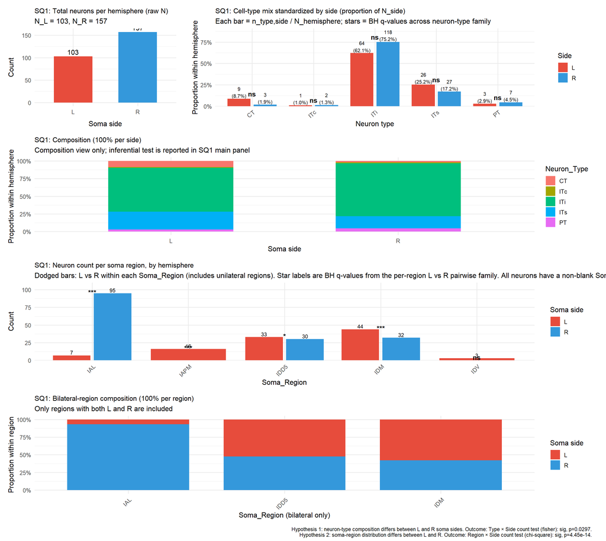

```r
if (!exists("sq1_region_side_test_txt")) {
  sq1_region_side_test_txt <- "Region × Side count test: insufficient bilateral regions"
}
sq1_caption_region <- paste0(
  "Hypothesis 2: soma-region distribution differs between L and R. ",
  "Outcome: ", sq1_region_side_test_txt, "."
)

n_L <- sum(meta$Soma_Side == "L")
n_R <- sum(meta$Soma_Side == "R")

# Per-type L vs R tests for SQ1 paired bars
sq1_type_pair_test <- meta %>%
  group_by(Neuron_Type) %>%
  summarise(
    n_L_type = sum(Soma_Side == "L"),
    n_R_type = sum(Soma_Side == "R"),
    .groups = "drop"
  ) %>%
  mutate(p_raw = mapply(.pair_prop_test, n_L_type, n_R_type, MoreArgs = list(nL = n_L, nR = n_R))) %>%
  add_family_inference(p_col = "p_raw", family_id = "sq1_type_pair_lr", adjust_method = "BH") %>%
  mutate(sig = sig_label) %>%
  left_join(
    sq1_by_side %>%
      group_by(Neuron_Type) %>%
      summarise(y = max(prop, na.rm = TRUE) + 0.06, .groups = "drop"),
    by = "Neuron_Type"
  )

sq1_p1 <- ggplot(meta, aes(x = Soma_Side, fill = Soma_Side)) +
  geom_bar(width = 0.6) +
  geom_text(
    stat = "count",
    aes(label = after_stat(count)),
    vjust = -0.35,
    size = 4
  ) +
  scale_fill_manual(values = side_cols) +
  labs(
    title = "SQ1: Total neurons per hemisphere (raw N)",
    subtitle = sprintf("N_L = %d, N_R = %d", n_L, n_R),
    x = "Soma side",
    y = "Count"
  ) +
  theme_minimal(base_size = 12) +
  theme(
    legend.position = "none",
    plot.margin = margin(8, 18, 8, 8)
  )

# Within each side, proportion per type (sums to 100% for L and separately for R)
sq1_p2 <- ggplot(sq1_by_side, aes(x = Neuron_Type, y = prop, fill = Soma_Side)) +
  geom_col(position = position_dodge(width = 0.85), width = 0.75) +
  geom_text(
    aes(label = sprintf("%d\n(%s)", n, percent(prop, accuracy = 0.1))),
    position = position_dodge(width = 0.85),
    vjust = -0.1,
    size = 2.85,
  ) +
  geom_text(
    data = sq1_type_pair_test,
    aes(x = Neuron_Type, y = y, label = sig),
    inherit.aes = FALSE,
    fontface = "bold",
    size = 4
  ) +
  scale_fill_manual(values = side_cols, name = "Side") +
  scale_y_continuous(labels = label_percent(accuracy = 1), expand = expansion(mult = c(0, 0.12))) +
  labs(
    title = "SQ1: Cell-type mix standardized by side (proportion of N_side)",
      subtitle = "Each bar = n_type,side / N_hemisphere; stars = BH q-values across neuron-type family",
    x = "Neuron type",
    y = "Proportion within hemisphere"
  ) +
  theme_minimal(base_size = 12) +
  theme(
    axis.text.x = element_text(angle = 40, hjust = 1),
    plot.margin = margin(8, 18, 8, 8)
  )

# 100% stacked: full composition per hemisphere on one axis
sq1_p3 <- ggplot(meta, aes(x = Soma_Side, fill = Neuron_Type)) +
  geom_bar(position = "fill", width = 0.55) +
  scale_y_continuous(labels = label_percent(accuracy = 1)) +
  labs(
    title = "SQ1: Composition (100% per side)",
    subtitle = "Composition view only; inferential test is reported in SQ1 main panel",
    x = "Soma side",
    y = "Proportion within hemisphere"
  ) +
  theme_minimal(base_size = 12) +
  theme(
    legend.position = "right",
    plot.margin = margin(8, 18, 8, 8)
  )

# Soma_Region hemisphere-neutral in prep.
# For display coverage, include both bilateral and unilateral non-blank regions.
meta_sq1_region_plot <- meta %>%
  filter(!is.na(Soma_Region), nzchar(trimws(as.character(Soma_Region)))) %>%
  mutate(Soma_Region = droplevels(Soma_Region))

n_drop_region <- nrow(meta) - nrow(meta_sq1_region_plot)
sq1_p4_sub <- if (n_drop_region > 0L) {
  sprintf("Excluded %d neuron(s) with missing/blank Soma_Region.", n_drop_region)
} else {
  "All neurons have a non-blank Soma_Region."
}

sq1_p3b <- NULL
if (nrow(meta_sq1_region_plot)) {
  sq1_region_pair_test <- meta_sq1_region_plot %>%
    group_by(Soma_Region) %>%
    summarise(
      n_L_region = sum(Soma_Side == "L"),
      n_R_region = sum(Soma_Side == "R"),
      .groups = "drop"
    ) %>%
    mutate(p_raw = mapply(.pair_prop_test, n_L_region, n_R_region, MoreArgs = list(nL = n_L, nR = n_R))) %>%
    add_family_inference(p_col = "p_raw", family_id = "sq1_region_pair_lr", adjust_method = "BH") %>%
    mutate(sig = sig_label) %>%
    left_join(
      meta_sq1_region_plot %>%
        count(Soma_Region, Soma_Side, name = "n") %>%
        group_by(Soma_Region) %>%
        summarise(y = max(n, na.rm = TRUE) + 1.5, .groups = "drop"),
      by = "Soma_Region"
    )

  sq1_p3b <- ggplot(meta_sq1_region_plot, aes(x = Soma_Region, fill = Soma_Side)) +
    geom_bar(position = position_dodge(width = 0.85), width = 0.78) +
    geom_text(
      stat = "count",
      aes(label = after_stat(count), group = Soma_Side),
      position = position_dodge(width = 0.85),
      vjust = -0.25,
      size = 3.2
    ) +
    geom_text(
      data = sq1_region_pair_test,
      aes(x = Soma_Region, y = y, label = sig),
      inherit.aes = FALSE,
      fontface = "bold",
      size = 4
    ) +
    scale_fill_manual(values = side_cols, name = "Soma side") +
    scale_y_continuous(expand = expansion(mult = c(0, 0.14))) +
    labs(
      title = "SQ1: Neuron count per soma region, by hemisphere",
      subtitle = paste0(
        "Dodged bars: L vs R within each Soma_Region (includes unilateral regions). ",
        "Star labels are BH q-values from the per-region L vs R pairwise family. ",
        sq1_p4_sub
      ),
      x = "Soma_Region",
      y = "Count"
    ) +
    theme_minimal(base_size = 12) +
    theme(
      axis.text.x = element_text(angle = 45, hjust = 1),
      legend.position = "right",
      plot.margin = margin(8, 18, 8, 8)
    )

  # Additional composition view restricted to bilateral regions only
  sq1_region_bilateral_prop <- meta_sq1_region %>%
    count(Soma_Region, Soma_Side, name = "n") %>%
    group_by(Soma_Region) %>%
    mutate(prop = n / sum(n)) %>%
    ungroup()

  sq1_p3c <- ggplot(sq1_region_bilateral_prop, aes(x = Soma_Region, y = prop, fill = Soma_Side)) +
    geom_col(position = "fill", width = 0.78) +
    scale_fill_manual(values = side_cols, name = "Soma side") +
    scale_y_continuous(labels = label_percent(accuracy = 1)) +
    labs(
      title = "SQ1: Bilateral-region composition (100% per region)",
      subtitle = "Only regions with both L and R are included",
      x = "Soma_Region (bilateral only)",
      y = "Proportion within region"
    ) +
    theme_minimal(base_size = 12) +
    theme(
      axis.text.x = element_text(angle = 45, hjust = 1),
      legend.position = "right",
      plot.margin = margin(8, 18, 8, 8)
    )
}

sq1_top <- (sq1_p1 | sq1_p2) + plot_layout(widths = c(1, 2.25), guides = "collect")

# Show each hypothesis caption once at the figure level
sq1_fig <- if (!is.null(sq1_p3b)) {
  patchwork::wrap_plots(
    if (exists("sq1_p3c", inherits = FALSE) && !is.null(sq1_p3c)) {
      list(sq1_top, sq1_p3, sq1_p3b, sq1_p3c)
    } else {
      list(sq1_top, sq1_p3, sq1_p3b)
    },
    ncol = 1
  ) +
    plot_annotation(caption = paste(sq1_caption_lr, sq1_caption_region, sep = "\n"))
} else {
  patchwork::wrap_plots(list(sq1_top, sq1_p3), ncol = 1) +
    plot_annotation(caption = sq1_caption_lr)
}

sq1_fig <- sq1_fig & theme(plot.title = element_text(size = 11.5))
# dev.new(width=14, height=10)
sq1_fig
```

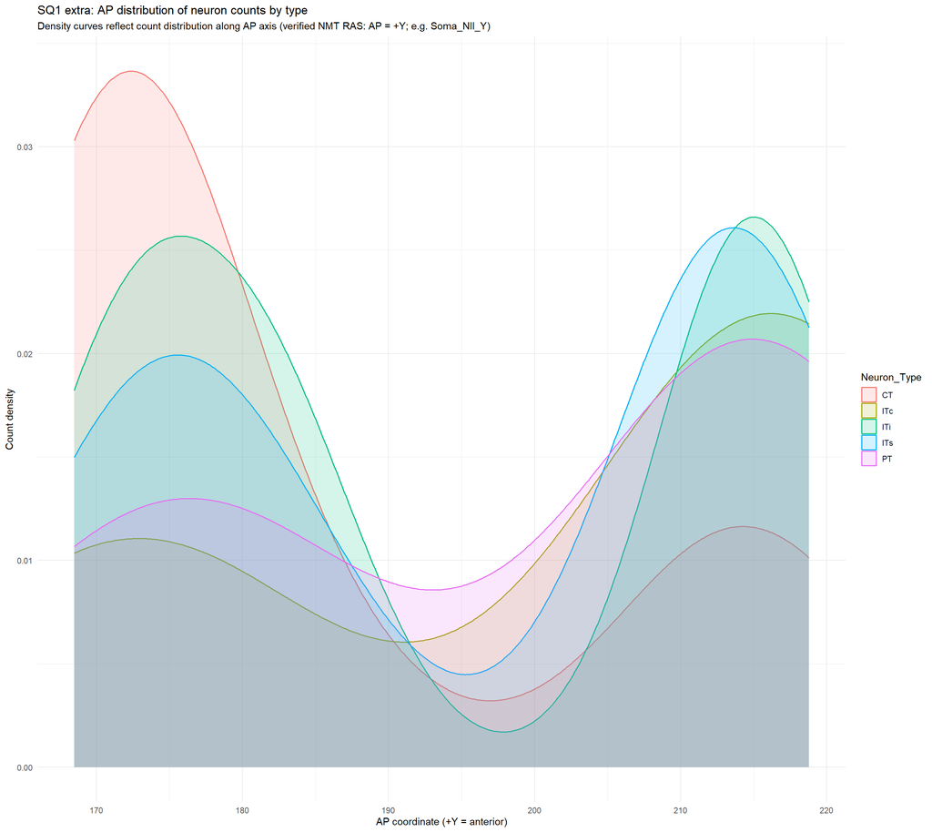

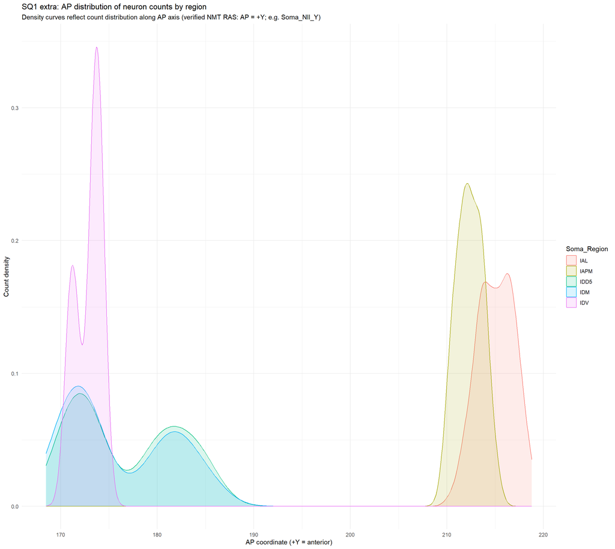

```r
save_plot(sq1_fig, "sq1_composition.png", width = 14, height = 14)
save_stats(sq1_lr_summary, "sq1_lr_summary.csv")
if (exists("sq1_region_side_summary", inherits = FALSE)) save_stats(sq1_region_side_summary, "sq1_region_side_summary.csv")
if (exists("sq1_region_type_summary", inherits = FALSE)) save_stats(sq1_region_type_summary, "sq1_region_type_summary.csv")
if (exists("sq1_type_pair_test", inherits = FALSE)) save_stats(sq1_type_pair_test, "sq1_type_pair_test.csv")
if (exists("sq1_region_pair_test", inherits = FALSE)) save_stats(sq1_region_pair_test, "sq1_region_pair_test.csv")
if (exists("sq1_by_side", inherits = FALSE)) save_table(sq1_by_side, "sq1_type_by_side_counts_and_props.csv")
if (exists("sq1_region_bilateral_prop", inherits = FALSE)) save_table(sq1_region_bilateral_prop, "sq1_region_bilateral_proportions.csv")

# SQ1 extra: AP-axis count density by type and by region
sq1_ap_df <- meta %>%
  dplyr::select(NeuronID, Soma_Side, Neuron_Type, Soma_Region, dplyr::any_of("AP_coord"))

if (!("AP_coord" %in% colnames(sq1_ap_df))) {
  ap_col_sq1 <- .pick_first_col(summary_sh, c(
    "Soma_NII_Y", "Soma_Phys_Y",
    "AP", "ap", "Soma_AP", "soma_ap", "Y", "y", "Soma_Y", "soma_y"
  ))
  if (!is.na(ap_col_sq1)) {
    sq1_ap_df <- sq1_ap_df %>%
      dplyr::select(-dplyr::any_of("AP_coord")) %>%
      left_join(
        summary_sh %>%
          transmute(NeuronID = NeuronID, AP_coord = as.numeric(.data[[ap_col_sq1]])),
        by = "NeuronID"
      )
  }
}

sq1_ap_df <- sq1_ap_df %>%
  filter(is.finite(AP_coord), !is.na(Neuron_Type), !is.na(Soma_Region))

if (nrow(sq1_ap_df) >= 10L) {
  sq1_ap_type_plot <- ggplot(sq1_ap_df, aes(x = AP_coord, color = Neuron_Type, fill = Neuron_Type)) +
    geom_density(alpha = 0.16, linewidth = 0.55, adjust = 1.0) +
    labs(
      title = "SQ1 extra: AP distribution of neuron counts by type",
      subtitle = "Density curves reflect count distribution along AP axis (verified NMT RAS: AP = +Y; e.g. Soma_NII_Y)",
      x = "AP coordinate (+Y = anterior)",
      y = "Count density"
    ) +
    theme_minimal(base_size = 11) +
    theme(legend.position = "right")
  print(sq1_ap_type_plot)
  save_plot(sq1_ap_type_plot, "sq1_ap_count_density_by_type.png", width = 12, height = 5.8)

  sq1_ap_region_plot <- ggplot(sq1_ap_df, aes(x = AP_coord, color = Soma_Region, fill = Soma_Region)) +
    geom_density(alpha = 0.14, linewidth = 0.45, adjust = 1.0) +
    labs(
      title = "SQ1 extra: AP distribution of neuron counts by region",
      subtitle = "Density curves reflect count distribution along AP axis (verified NMT RAS: AP = +Y; e.g. Soma_NII_Y)",
      x = "AP coordinate (+Y = anterior)",
      y = "Count density"
    ) +
    theme_minimal(base_size = 11) +
    theme(legend.position = "right")
  print(sq1_ap_region_plot)
  save_plot(sq1_ap_region_plot, "sq1_ap_count_density_by_region.png", width = 12, height = 5.8)
} else {
  message("SQ1 extra: too few valid AP coordinates for AP count-density plots.")
}
```

```r
cleanup_vars(c(
  "sq1_p1", "sq1_p2", "sq1_p3", "sq1_p3b", "sq1_p3c",
  "sq1_top", "sq1_fig",
  "sq1_type_pair_test", "sq1_region_pair_test", "sq1_region_bilateral_prop",
  "sq1_ap_df", "sq1_ap_type_plot", "sq1_ap_region_plot"
))
```

# Part B: Projection-Strength Laterality Analyses

This section is specialized for **projection strength** (continuous outcomes; Wilcoxon / distributional comparisons / multivariate distance models).

## SQ2: Projection-strength counterparts to SQ1 (L/R and Soma_Region)

**SQ2a (L/R counterpart):** Within each `Neuron_Type`, compare total projection strength between L and R (`wilcox.test(total ~ Soma_Side)` with BH correction across types).  
**SQ2b (Region counterpart):** In **bilateral** regions (both L and R present), compare total strength by hemisphere overall within each region and within `Soma_Region × Neuron_Type` strata (BH across strata).

**Note**: `total` is a matrix-derived projection-strength summary, not necessarily physical axon length unless source columns are length-based.

```r
# SQ2 overview:
# - Univariate strength-focused comparisons (L/R by type and by region).
# - Includes descriptive density/box visuals, Wilcoxon summaries, and saved extra plots.
# - Spatial/AP views are descriptive and use robust coordinate fallback.
strength <- data.frame(
  NeuronID = meta$NeuronID,
  Soma_Side = meta$Soma_Side,
  Neuron_Type = meta$Neuron_Type,
  Soma_Region = meta$Soma_Region,
  ipsi = colSums(mat_ipsi),
  contra = colSums(mat_contra),
  total = colSums(mat_ipsi) + colSums(mat_contra),
  stringsAsFactors = FALSE
)

side_cols <- c(L = "#E74C3C", R = "#3498DB")

# ---- New SQ2 views: region-level density cloud + AP/ML spatial density ----
strength_region_mean <- strength %>%
  filter(!is.na(Soma_Region), nzchar(trimws(as.character(Soma_Region)))) %>%
  group_by(Soma_Region, Soma_Side) %>%
  summarise(
    mean_total = mean(total, na.rm = TRUE),
    median_total = median(total, na.rm = TRUE),
    n = n(),
    .groups = "drop"
  )

sq2_region_density_with_mean <- strength %>%
  filter(!is.na(Soma_Region), nzchar(trimws(as.character(Soma_Region))))

sq2_region_mean_plot <- ggplot(
  sq2_region_density_with_mean,
  aes(x = total, color = Soma_Region, fill = Soma_Region)
) +
  geom_density(alpha = 0.18, linewidth = 0.35) +
  labs(
    title = "SQ2 extra: Region-wise strength density cloud (all regions stacked)",
    subtitle = "Each colored cloud is one Soma_Region; all regions shown in one panel",
    x = "Total projection strength",
    y = "Density"
  ) +
  theme_minimal(base_size = 11) +
  theme(legend.position = "right")

# Coordinate source is now meta dataframe (AP_coord / ML_coord prepared in prep)
strength_spatial <- strength %>%
  left_join(meta %>% dplyr::select(NeuronID, dplyr::any_of(c("AP_coord", "ML_coord"))), by = "NeuronID")

# Fallback: if current session `meta` has no coords (e.g. prep chunk not re-run),
# recover AP/ML directly from `summary_sh` so SQ2 spatial plot still works.
if (!all(c("AP_coord", "ML_coord") %in% colnames(strength_spatial))) {
  ap_col_sq2 <- .pick_first_col(summary_sh, c(
    "Soma_NII_Y", "Soma_Phys_Y",
    "AP", "ap", "Soma_AP", "soma_ap", "Y", "y", "Soma_Y", "soma_y"
  ))
  ml_col_sq2 <- .pick_first_col(summary_sh, c(
    "Soma_NII_X", "Soma_Phys_X",
    "ML", "ml", "Soma_ML", "soma_ml", "X", "x", "Soma_X", "soma_x"
  ))

  if (!is.na(ap_col_sq2) && !is.na(ml_col_sq2)) {
    coord_sq2 <- summary_sh %>%
      transmute(
        NeuronID = NeuronID,
        AP_coord = as.numeric(.data[[ap_col_sq2]]),
        ML_coord = as.numeric(.data[[ml_col_sq2]])
      )
    strength_spatial <- strength %>%
      left_join(coord_sq2, by = "NeuronID")
    message("SQ2 extra: using fallback AP/ML coords from Summary sheet in current chunk.")
  }
}

sq2_spatial_plot <- NULL
if (all(c("AP_coord", "ML_coord") %in% colnames(strength_spatial))) {
  strength_spatial <- strength_spatial %>%
    filter(is.finite(AP_coord), is.finite(ML_coord), is.finite(total))

  if (nrow(strength_spatial) >= 10L) {
    spatial_long <- bind_rows(
      strength_spatial %>%
        transmute(Soma_Side, total, Axis = "AP", Coord = AP_coord),
      strength_spatial %>%
        transmute(Soma_Side, total, Axis = "ML", Coord = ML_coord)
    )

    sq2_spatial_plot <- ggplot(
      spatial_long,
      aes(x = Coord, color = Soma_Side, fill = Soma_Side, weight = total)
    ) +
      geom_density(alpha = 0.20, linewidth = 0.55, adjust = 1.0) +
      facet_wrap(~ Axis, ncol = 1, scales = "free_x") +
      scale_color_manual(values = side_cols, name = "Side") +
      scale_fill_manual(values = side_cols, name = "Side") +
      labs(
        title = "SQ2 extra: Projection-strength-weighted spatial density",
        subtitle = "Density-cloud style along AP/ML axes (weights = total projection strength). Orientation verified from NMT affine (RAS): AP = +Y, ML = +X.",
        x = "Coordinate value (AP: +Y anterior; ML: +X rightward)",
        y = "Weighted density"
      ) +
      theme_minimal(base_size = 11) +
      theme(legend.position = "right")
  } else {
    message("SQ2 extra: no neurons with valid AP/ML coordinates after filtering.")
  }
} else {
  message("SQ2 extra: AP/ML columns not found in meta; spatial plot skipped.")
}

strength_cmp <- strength %>%
  group_by(Neuron_Type) %>%
  filter(n_distinct(Soma_Side) == 2L) %>%
  ungroup()

# Left panel: only types with both L and R neurons (drop types present on one side only, e.g. all-ITc-on-one-side)
sq2_density <- ggplot(strength_cmp, aes(x = total, fill = Soma_Side)) +
  geom_density(alpha = 0.45, linewidth = 0.3) +
  facet_wrap(~Neuron_Type, scales = "free") +
  scale_fill_manual(values = side_cols, name = "Side") +
  labs(
    title = "SQ2: Distribution of total strength (ipsi + contra)",
    x = "Total projection strength",
    y = "Density"
  ) +
  theme_minimal(base_size = 12) +
  theme(
    strip.text = element_text(size = 11, face = "plain"),
    axis.text = element_text(size = 10)
  )

sq2_n_lab <- strength_cmp %>%
  group_by(Neuron_Type, Soma_Side) %>%
  summarise(
    n = n(),
    y = max(total, na.rm = TRUE) * 1.08,
    .groups = "drop"
  )

sq2_type_q_labels <- strength_cmp %>%
  group_by(Neuron_Type) %>%
  filter(n_distinct(Soma_Side) == 2L, n() >= 4L) %>%
  summarise(
    p_raw = tryCatch(wilcox.test(total ~ Soma_Side)$p.value, error = function(e) NA_real_),
    y = max(total, na.rm = TRUE) * 1.16,
    .groups = "drop"
  ) %>%
  add_family_inference(p_col = "p_raw", family_id = "sq2_type_lr", adjust_method = "BH")

# Right panel: matches laterality_hypothesis_testing.Rmd style — one figure, x = neuron type
sq2_box <- ggplot(strength_cmp, aes(x = Neuron_Type, y = total, fill = Soma_Side)) +
  geom_boxplot(
    position = position_dodge(width = 0.85),
    width = 0.62,
    alpha = 0.88,
    outlier.size = 1
  ) +
  geom_text(
    data = sq2_n_lab,
    aes(x = Neuron_Type, y = y, label = paste0("n=", n), group = Soma_Side),
    position = position_dodge(width = 0.85),
    size = 3.2,
    inherit.aes = FALSE
  ) +
  geom_text(
    data = sq2_type_q_labels,
    aes(x = Neuron_Type, y = y, label = sig_label),
    inherit.aes = FALSE,
    fontface = "bold",
    size = 4
  ) +
  scale_fill_manual(values = side_cols, name = "Side") +
  labs(
    title = "SQ2: Total projection by type & side (Wilcoxon L vs R within each type)",
    subtitle = "Stars = BH q-values across neuron-type family",
    x = "Neuron type",
    y = "Total projection strength"
  ) +
  theme_minimal(base_size = 12) +
  theme(axis.text.x = element_text(angle = 45, hjust = 1))

sq2_row1 <- (sq2_density | sq2_box) +
  plot_layout(widths = c(1, 1), guides = "collect") &
  theme(plot.title = element_text(size = 12))

strength_reg <- strength %>%
  filter(!is.na(Soma_Region), nzchar(trimws(as.character(Soma_Region)))) %>%
  mutate(Soma_Region = droplevels(factor(Soma_Region)))

all_region_levels <- strength_reg %>%
  distinct(Soma_Region) %>%
  pull(Soma_Region)

bilateral_region_levels <- strength_reg %>%
  group_by(Soma_Region) %>%
  filter(n_distinct(Soma_Side) == 2L) %>%
  group_keys() %>%
  pull(Soma_Region)

strength_bilateral_regions <- strength_reg %>%
  filter(Soma_Region %in% bilateral_region_levels) %>%
  mutate(Soma_Region = droplevels(Soma_Region))

sq2_region_density <- NULL
wt_region_overall <- NULL
wt_region_type <- NULL

if (nrow(strength_reg) >= 2L && length(all_region_levels)) {
  sq2_region_density <- ggplot(strength_reg, aes(x = total, fill = Soma_Side)) +
    geom_density(alpha = 0.45, linewidth = 0.3) +
    facet_wrap(~ Soma_Region, nrow = 1L, scales = "free") +
    scale_fill_manual(values = side_cols, name = "Side") +
    labs(
      title = "SQ2 (regions): Total strength by hemisphere across all soma regions",
      subtitle = "All neuron types pooled; unilateral regions show one-side density only",
      x = "Total projection strength",
      y = "Density"
    ) +
    theme_minimal(base_size = 12) +
    theme(
      strip.text = element_text(size = 10, face = "plain"),
      legend.position = "bottom"
    )
}

if (nrow(strength_bilateral_regions) >= 4L && length(bilateral_region_levels)) {
  wt_region_overall <- strength_bilateral_regions %>%
    group_by(Soma_Region) %>%
    filter(n_distinct(Soma_Side) == 2L, n() >= 4L) %>%
    summarise(
      p_wilcox_total = tryCatch(
        wilcox.test(total ~ Soma_Side)$p.value,
        error = function(e) NA_real_
      ),
      n = n(),
      n_L = sum(Soma_Side == "L"),
      n_R = sum(Soma_Side == "R"),
      .groups = "drop"
    ) %>%
    add_family_inference(p_col = "p_wilcox_total", family_id = "sq2_region_lr_overall", adjust_method = "BH") %>%
    mutate(p_wilcox_BH = p_adj)

  wt_region_type <- strength_bilateral_regions %>%
    group_by(Soma_Region, Neuron_Type) %>%
    filter(n_distinct(Soma_Side) == 2L, n() >= 4L) %>%
    summarise(
      p_wilcox_total = tryCatch(
        wilcox.test(total ~ Soma_Side)$p.value,
        error = function(e) NA_real_
      ),
      n = n(),
      n_L = sum(Soma_Side == "L"),
      n_R = sum(Soma_Side == "R"),
      .groups = "drop"
    ) %>%
    add_family_inference(p_col = "p_wilcox_total", family_id = "sq2_region_type_lr", adjust_method = "BH") %>%
    mutate(p_wilcox_BH = p_adj)

  cat("SQ2: Wilcoxon total ~ Side, bilateral regions (all types pooled)\n")
  print(wt_region_overall)
  cat("SQ2: Wilcoxon total ~ Side within Soma_Region × Neuron_Type (BH across strata)\n")
  print(wt_region_type)
}
```

```
## SQ2: Wilcoxon total ~ Side, bilateral regions (all types pooled)
##   Soma_Region p_wilcox_total   n n_L n_R     p_raw     p_adj adjust_method
## 1         IAL      0.2777609 102   7  95 0.2777609 0.6232753            BH
## 2        IDD5      0.4155169  63  33  30 0.4155169 0.6232753            BH
## 3         IDM      0.6490935  76  44  32 0.6490935 0.6490935            BH
##               family_id significant sig_label      p_BH      q_BH p_wilcox_BH
## 1 sq2_region_lr_overall       FALSE        ns 0.6232753 0.6232753   0.6232753
## 2 sq2_region_lr_overall       FALSE        ns 0.6232753 0.6232753   0.6232753
## 3 sq2_region_lr_overall       FALSE        ns 0.6490935 0.6490935   0.6490935
## SQ2: Wilcoxon total ~ Side within Soma_Region × Neuron_Type (BH across strata)
##   Soma_Region Neuron_Type p_wilcox_total  n n_L n_R      p_raw     p_adj
## 1         IAL         ITi     0.02656188 73   4  69 0.02656188 0.2124950
## 2         IAL         ITs     0.22222222 18   1  17 0.22222222 0.8888889
## 3         IAL          PT     0.33333333  6   1   5 0.33333333 0.8888889
## 4        IDD5          CT     0.80000000  5   4   1 0.80000000 0.9212121
```

[output cut: 22 more lines]

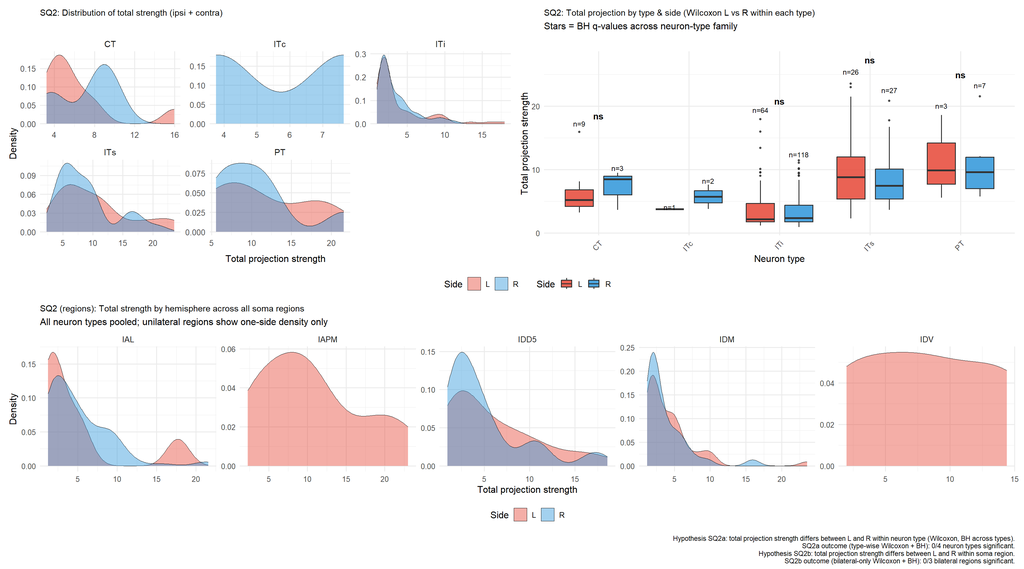

```r
sq2_region_outcome_txt <- if (!is.null(wt_region_overall) && nrow(wt_region_overall)) {
  n_sig <- sum(wt_region_overall$significant, na.rm = TRUE)
  sprintf(
    "SQ2b outcome (bilateral-only Wilcoxon + BH): %d/%d bilateral regions significant.",
    n_sig,
    nrow(wt_region_overall)
  )
} else {
  "SQ2b outcome: insufficient bilateral regions for inferential region-side test."
}

sq2a_eval <- strength_cmp %>%
  group_by(Neuron_Type) %>%
  filter(n_distinct(Soma_Side) == 2L, n() >= 4L) %>%
  summarise(
    p_raw = tryCatch(wilcox.test(total ~ Soma_Side)$p.value, error = function(e) NA_real_),
    .groups = "drop"
  ) %>%
  add_family_inference(p_col = "p_raw", family_id = "sq2_type_lr", adjust_method = "BH")
sq2a_outcome_txt <- if (nrow(sq2a_eval)) {
  sprintf(
    "SQ2a outcome (type-wise Wilcoxon + BH): %d/%d neuron types significant.",
    sum(sq2a_eval$significant, na.rm = TRUE),
    nrow(sq2a_eval)
  )
} else {
  "SQ2a outcome: insufficient type strata for L/R inferential test."
}

sq2_caption <- paste(
  "Hypothesis SQ2a: total projection strength differs between L and R within neuron type (Wilcoxon, BH across types).",
  sq2a_outcome_txt,
  "Hypothesis SQ2b: total projection strength differs between L and R within soma region.",
  sq2_region_outcome_txt,
  sep = "\n"
)
sq2_fig <- if (!is.null(sq2_region_density)) {
  (sq2_row1) / sq2_region_density +
    plot_layout(heights = c(1, 0.68), guides = "collect")
} else {
  message("SQ2: No valid Soma_Region entries; skipping region-level strength plots.")
  sq2_row1
}
sq2_fig <- sq2_fig +
  plot_annotation(caption = sq2_caption) &
  theme(plot.title = element_text(size = 11), legend.position = "bottom")
print(sq2_fig)
```

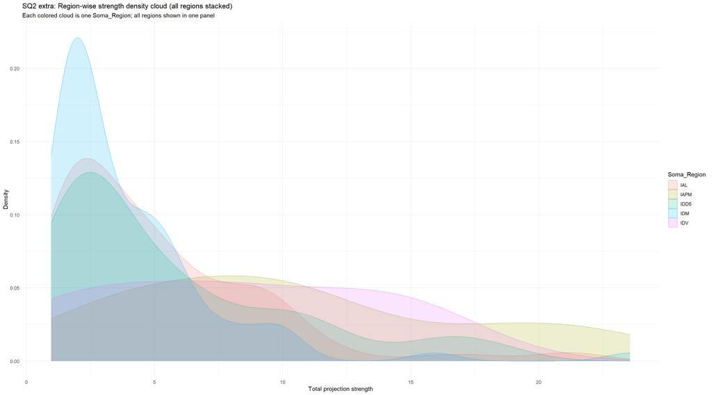

```r
save_plot(sq2_fig, "sq2_univariate_strength.png", width = 18, height = 10)
print(sq2_region_mean_plot)
```

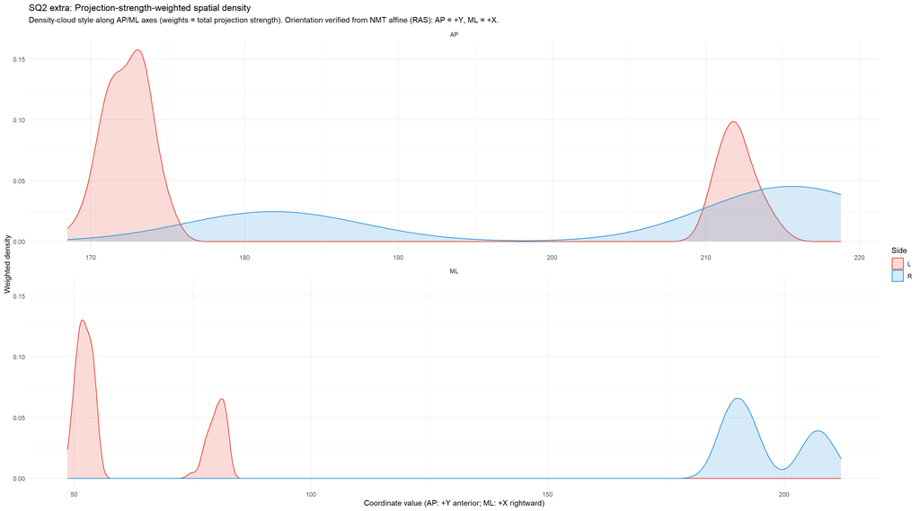

```r
save_plot(sq2_region_mean_plot, "sq2_region_mean_strength.png", width = 15, height = 7)

if (!is.null(sq2_spatial_plot)) {
  print(sq2_spatial_plot)
  save_plot(sq2_spatial_plot, "sq2_ap_ml_strength_density.png", width = 12, height = 5.8)
}
```

```r
cleanup_vars(c(
  "sq2_density", "sq2_box", "sq2_row1", "sq2_region_density", "sq2_fig",
  "sq2_n_lab", "strength_reg", "strength_bilateral_regions", "all_region_levels", "bilateral_region_levels",
  "strength_region_mean", "sq2_region_density_with_mean", "sq2_region_mean_plot",
  "strength_spatial", "sq2_spatial_plot", "sq2_type_q_labels"
))

# Per-type Wilcoxon on total strength (no region stratification); BH across types
wt <- strength %>%
  group_by(Neuron_Type) %>%
  filter(n_distinct(Soma_Side) == 2, n() >= 4) %>%
  summarise(
    p_wilcox_total = tryCatch(
      wilcox.test(total ~ Soma_Side)$p.value,
      error = function(e) NA_real_
    ),
    n = n(),
    .groups = "drop"
  ) %>%
  add_family_inference(p_col = "p_wilcox_total", family_id = "sq2_type_lr", adjust_method = "BH") %>%
  mutate(p_wilcox_BH = p_adj)
print(wt)
```

```
##   Neuron_Type p_wilcox_total   n     p_raw     p_adj adjust_method   family_id
## 1          CT      0.4818182  12 0.4818182 0.9636364            BH sq2_type_lr
## 2         ITi      0.8469527 182 0.8469527 1.0000000            BH sq2_type_lr
## 3         ITs      0.4111814  53 0.4111814 0.9636364            BH sq2_type_lr
## 4          PT      1.0000000  10 1.0000000 1.0000000            BH sq2_type_lr
##   significant sig_label      p_BH      q_BH p_wilcox_BH
## 1       FALSE        ns 0.9636364 0.9636364   0.9636364
## 2       FALSE        ns 1.0000000 1.0000000   1.0000000
## 3       FALSE        ns 0.9636364 0.9636364   0.9636364
## 4       FALSE        ns 1.0000000 1.0000000   1.0000000
```

```r
save_stats(wt, "sq2_type_wilcox.csv")
if (!is.null(wt_region_overall) && nrow(wt_region_overall)) save_stats(wt_region_overall, "sq2_region_overall_wilcox.csv")
if (!is.null(wt_region_type) && nrow(wt_region_type)) save_stats(wt_region_type, "sq2_region_type_wilcox.csv")
if (exists("sq2a_eval", inherits = FALSE)) save_stats(sq2a_eval, "sq2_type_eval_bh.csv")
```

### SQ2c (v2): `lm` on log total strength (side after neuron type)

**Interpretation:** Type I **ANOVA** tests `Soma_Side` after `Neuron_Type`, addressing uneven L/R *composition* across types. **`drop1(..., test = "F")`** gives marginal deletion tests (each term given others). Report both briefly in the HTML; the workbook stores **`SQ2_lm_anova`** and **`SQ2_lm_drop1`**.

```r
fit_total <- tryCatch(
  lm(log1p(total) ~ Neuron_Type + Soma_Side, data = strength),
  error = function(e) NULL
)
if (is.null(fit_total)) {
  message("SQ2 v2: lm(log1p(total) ~ ...) failed (e.g. rank deficiency).")
  sq2_lm_anova <- NULL
  sq2_lm_drop1 <- NULL
  sq2_lm_side <- NULL
} else {
  sq2_lm_anova <- as.data.frame(anova(fit_total))
  sq2_lm_anova$term <- rownames(sq2_lm_anova)
  rownames(sq2_lm_anova) <- NULL
  sq2_lm_drop1 <- as.data.frame(drop1(fit_total, test = "F"))
  sq2_lm_drop1$term <- rownames(sq2_lm_drop1)
  rownames(sq2_lm_drop1) <- NULL
  sq2_lm_side <- sq2_lm_drop1 %>% filter(term == "Soma_Side")
  cat("SQ2 v2: ANOVA (Type I; order = Neuron_Type, then Soma_Side)\n")
  print(sq2_lm_anova)
  cat("\nSQ2 v2: drop1 marginal F-tests\n")
  print(sq2_lm_drop1)
}
```

```
## SQ2 v2: ANOVA (Type I; order = Neuron_Type, then Soma_Side)
##    Df      Sum Sq    Mean Sq    F value       Pr(>F)        term
## 1   4 36.18027517 9.04506879 38.3197014 4.425973e-25 Neuron_Type
## 2   1  0.05073996 0.05073996  0.2149614 6.433033e-01   Soma_Side
## 3 254 59.95473315 0.23604226         NA           NA   Residuals
##
## SQ2 v2: drop1 marginal F-tests
##   Df   Sum of Sq      RSS       AIC    F value       Pr(>F)        term
## 1 NA          NA 59.95473 -369.4439         NA           NA      <none>
## 2  4 35.40394542 95.35868 -256.7894 37.4974654 1.223044e-24 Neuron_Type
## 3  1  0.05073996 60.00547 -371.2239  0.2149614 6.433033e-01   Soma_Side
```

```r
if (!is.null(sq2_lm_anova)) save_stats(sq2_lm_anova, "sq2c_lm_anova.csv")
if (!is.null(sq2_lm_drop1)) save_stats(sq2_lm_drop1, "sq2c_lm_drop1.csv")
if (!is.null(sq2_lm_side) && nrow(sq2_lm_side)) save_stats(sq2_lm_side, "sq2c_lm_soma_side_row.csv")
```

## SQ3: Do left and right differ in **multivariate projection pattern** (target-region vectors)?

**Hypothesis**: In the high-dimensional space of region × strength, the L vs R clouds differ in location and/or spread.  
**Why ipsi-only here?** We use `mat_ipsi` to isolate hemisphere-specific targeting and avoid a trivial side-coupling that can appear when ipsi + contra are pooled (because contra definitions are side-referenced). This keeps the distance model focused on within-hemisphere projection organization.  
**Steps**: (1) neuron × region matrix (`mat_ipsi`) → Bray–Curtis dissimilarities between neurons; (2) `adonis2` (PERMANOVA) on `Side`; (3) `betadisper` + `permutest` to test dispersion homogeneity (with euclidification for Bray–Curtis in this step: `sqrt.dist=TRUE`, `add=\"lingoes\"`); (4) PCoA for ordination. **Caveat**: PERMANOVA assumes **exchangeability** of residuals under permutation; heterogeneity of dispersion can inflate false positives, hence the explicit `betadisper` check. $R^2$ is **partial variance explained** by `Side` in the pseudo-F framework, not OLS $R^2$.

```r
ipsi_nr <- t(mat_ipsi) # neuron x region
side <- meta$Soma_Side[match(rownames(ipsi_nr), meta$NeuronID)]

# Profile-normalized matrix (composition-like view)
ipsi_tot <- rowSums(ipsi_nr)
ipsi_prop <- ipsi_nr
ok_tot <- ipsi_tot > 0
ipsi_prop[ok_tot, ] <- ipsi_nr[ok_tot, , drop = FALSE] / ipsi_tot[ok_tot]

# Presence/absence matrix for Jaccard
ipsi_pa <- ipsi_nr > 0

# Aitchison via CLR + Euclidean with a small pseudocount
pos_vals <- ipsi_nr[ipsi_nr > 0]
pseudocount <- if (length(pos_vals)) min(pos_vals) / 2 else 1e-6
ipsi_clr <- log(ipsi_nr + pseudocount) - rowMeans(log(ipsi_nr + pseudocount))

dist_list <- list(
  bray_raw = vegdist(ipsi_nr, method = "bray"),
  bray_prop = vegdist(ipsi_prop, method = "bray"),
  jaccard_pa = vegdist(ipsi_pa, method = "jaccard", binary = TRUE),
  aitchison_clr = dist(ipsi_clr)
)

sq3_multi_tab <- lapply(names(dist_list), function(nm) {
  d <- dist_list[[nm]]
  side_d <- side[match(labels(d), rownames(ipsi_nr))]
  ado_i <- adonis2(d ~ side_d, permutations = PERM_N, by = "margin")

  # Euclidify for dispersion check when distance is non-Euclidean
  bd_i <- betadisper(d, side_d, type = "centroid", sqrt.dist = TRUE, add = "lingoes")
  bd_perm_i <- permutest(bd_i, permutations = PERM_N)
  p_bd <- suppressWarnings(as.numeric(bd_perm_i$tab[1, "Pr(>F)"]))

  data.frame(
    distance = nm,
    R2 = as.numeric(ado_i$R2[1]),
    p_permanova = as.numeric(ado_i$`Pr(>F)`[1]),
    p_betadisper = p_bd
  )
}) %>%
  bind_rows() %>%
  add_family_inference(p_col = "p_permanova", family_id = "sq3_multidistance_permanova", adjust_method = "BH") %>%
  mutate(
    p_permanova_BH = p_adj,
    significant_permanova = significant,
    sig_permanova = sig_label,
    significant_betadisper = p_betadisper < 0.05,
    sig_betadisper = p_to_sig(p_betadisper)
  )
print(sq3_multi_tab)
```

```
##        distance         R2 p_permanova p_betadisper p_raw p_adj adjust_method
## 1      bray_raw 0.06912942       0.001        0.014 0.001 0.001            BH
## 2     bray_prop 0.06267244       0.001        0.014 0.001 0.001            BH
## 3    jaccard_pa 0.05142580       0.001        0.112 0.001 0.001            BH
## 4 aitchison_clr 0.03413675       0.001        0.632 0.001 0.001            BH
##                     family_id significant sig_label  p_BH  q_BH p_permanova_BH
## 1 sq3_multidistance_permanova        TRUE        ** 0.001 0.001          0.001
## 2 sq3_multidistance_permanova        TRUE        ** 0.001 0.001          0.001
## 3 sq3_multidistance_permanova        TRUE        ** 0.001 0.001          0.001
## 4 sq3_multidistance_permanova        TRUE        ** 0.001 0.001          0.001
##   significant_permanova sig_permanova significant_betadisper sig_betadisper
## 1                  TRUE            **                   TRUE              *
## 2                  TRUE            **                   TRUE              *
## 3                  TRUE            **                  FALSE             ns
## 4                  TRUE            **                  FALSE             ns
```

```r
# --- v2: covariate-adjusted PERMANOVA (rows match `ipsi_nr` / dist_list) ---
df_sq3 <- meta[match(rownames(ipsi_nr), meta$NeuronID), , drop = FALSE]
df_sq3 <- transmute(
  df_sq3,
  NeuronID = NeuronID,
  Neuron_Type = factor(Neuron_Type),
  Soma_Side = factor(Soma_Side, levels = c("L", "R")),
  Soma_Region = droplevels(factor(Soma_Region))
)
stopifnot(all.equal(as.character(df_sq3$NeuronID), rownames(ipsi_nr)))

sq3_adjusted_list <- list()
for (nm in names(dist_list)) {
  d <- dist_list[[nm]]
  a_ts <- tryCatch(
    adonis2(d ~ Neuron_Type + Soma_Side, data = df_sq3, permutations = PERM_N, by = "margin"),
    error = function(e) NULL
  )
  if (!is.null(a_ts)) {
    tt <- as.data.frame(a_ts)
    tt$term <- rownames(tt)
    rownames(tt) <- NULL
    tt$distance <- nm
    tt$model <- "~ Neuron_Type + Soma_Side"
    sq3_adjusted_list[[length(sq3_adjusted_list) + 1L]] <- tt
  }
  a_trs <- tryCatch(
    adonis2(
      d ~ Neuron_Type + Soma_Region + Soma_Side,
      data = df_sq3,
      permutations = PERM_N,
      by = "margin"
    ),
    error = function(e) NULL
  )
  if (!is.null(a_trs)) {
    tt <- as.data.frame(a_trs)
    tt$term <- rownames(tt)
    rownames(tt) <- NULL
    tt$distance <- nm
    tt$model <- "~ Neuron_Type + Soma_Region + Soma_Side"
    sq3_adjusted_list[[length(sq3_adjusted_list) + 1L]] <- tt
  }
}
sq3_adjusted_tab <- if (length(sq3_adjusted_list)) {
  res <- bind_rows(sq3_adjusted_list)
  pcol <- names(res)[grepl("^Pr\\(", names(res))]
  if (length(pcol) == 1L) {
    res$sig_label <- p_to_sig(as.numeric(res[[pcol]]))
  } else {
    res$sig_label <- NA_character_
  }
  res
} else {
  message("SQ3 v2: adjusted PERMANOVA tables could not be built.")
  NULL
}
if (!is.null(sq3_adjusted_tab) && nrow(sq3_adjusted_tab)) {
  cat("\nSQ3 v2: Adjusted PERMANOVA (by = margin). Soma_Side row = partial effect after preceding terms in formula.\n")
  print(sq3_adjusted_tab)
}
```

```
##
## SQ3 v2: Adjusted PERMANOVA (by = margin). Soma_Side row = partial effect after preceding terms in formula.
##     Df     SumOfSqs          R2         F Pr(>F)        term      distance
## 1    4 9.892931e+00 0.138166321 11.067887  0.001 Neuron_Type      bray_raw
## 2    1 4.833442e+00 0.067504660 21.629988  0.001   Soma_Side      bray_raw
## 3  254 5.675890e+01 0.792704250        NA     NA    Residual      bray_raw
## 4  259 7.160161e+01 1.000000000        NA     NA       Total      bray_raw
## 5    4 8.900996e+00 0.124312788 21.678733  0.001 Neuron_Type      bray_raw
## 6    4 3.109724e+01 0.434309261 75.738584  0.001 Soma_Region      bray_raw
## 7    1 2.616970e-01 0.003654904  2.549495  0.063   Soma_Side      bray_raw
## 8  250 2.566166e+01 0.358394987        NA     NA    Residual      bray_raw
## 9  259 7.160161e+01 1.000000000        NA     NA       Total      bray_raw
## 10   4 1.090478e+01 0.144292235 11.553782  0.001 Neuron_Type     bray_prop
## 11   1 4.645057e+00 0.061463490 19.686042  0.001   Soma_Side     bray_prop
## 12 254 5.993305e+01 0.793035322        NA     NA    Residual     bray_prop
```

[output cut: 61 more lines]

```r
# SQ3-specific sparsity diagnostics on the matrices used in this section.
sq3_sparsity <- bind_rows(
  matrix_sparsity(t(ipsi_nr), "sq3_ipsi_raw_region_by_neuron"),
  matrix_sparsity(t(ipsi_prop), "sq3_ipsi_profile_normalized"),
  matrix_sparsity(t(ipsi_pa), "sq3_ipsi_presence_absence")
) %>%
  mutate(zero_percent = 100 * zero_fraction)
print(sq3_sparsity)
```

```
##                          matrix n_regions n_neurons zero_fraction
## 1 sq3_ipsi_raw_region_by_neuron        57       260     0.9482456
## 2   sq3_ipsi_profile_normalized        57       260     0.9482456
## 3     sq3_ipsi_presence_absence        57       260     0.9482456
##   nonzero_fraction mean_nonzero_targets_per_neuron
## 1       0.05175439                            2.95
## 2       0.05175439                            2.95
## 3       0.05175439                            2.95
##   median_nonzero_targets_per_neuron mean_neurons_per_region
## 1                                 2                13.45614
## 2                                 2                13.45614
## 3                                 2                13.45614
##   median_neurons_per_region zero_percent
## 1                         4     94.82456
## 2                         4     94.82456
## 3                         4     94.82456
```

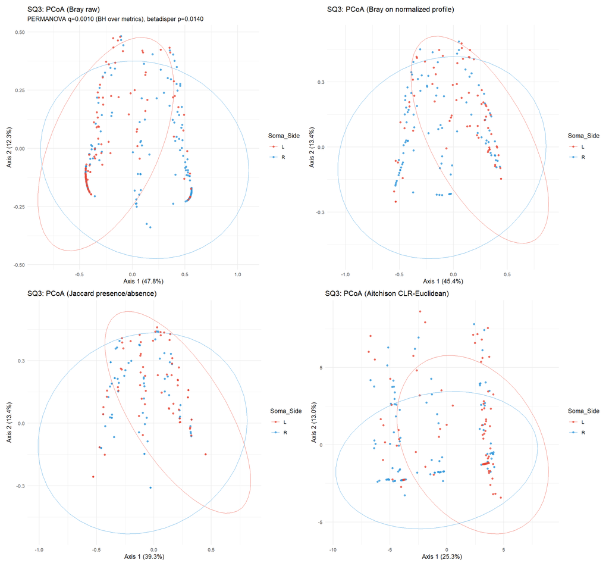

```r
# Keep legacy export variables based on primary metric (bray_raw)
sq3_summary <- sq3_multi_tab %>%
  filter(distance == "bray_raw") %>%
  transmute(
    term = "side",
    R2 = R2,
    p = p_permanova,
    significant = significant_permanova,
    sig_label = sig_permanova
  )
sq3_betadisper <- sq3_multi_tab %>%
  filter(distance == "bray_raw") %>%
  transmute(
    p = p_betadisper,
    significant = significant_betadisper,
    sig_label = sig_betadisper
  )

ord_plot <- function(d, title, subtitle = NULL) {
  md <- cmdscale(d, k = 2, eig = TRUE)
  eig_pos <- pmax(0, md$eig)
  pct <- if (sum(eig_pos) > 0) eig_pos / sum(eig_pos) * 100 else c(NA_real_, NA_real_)
  odf <- data.frame(
    NeuronID = labels(d),
    Axis1 = md$points[, 1],
    Axis2 = md$points[, 2]
  ) %>%
    left_join(meta, by = "NeuronID")
  ggplot(odf, aes(.data$Axis1, .data$Axis2, color = .data$Soma_Side)) +
    geom_point(alpha = 0.8) +
    stat_ellipse(level = 0.95, linewidth = 0.35) +
    scale_color_manual(values = c(L = "#E74C3C", R = "#3498DB")) +
    labs(
      title = title,
      subtitle = subtitle,
      x = sprintf("Axis 1 (%.1f%%)", pct[1]),
      y = sprintf("Axis 2 (%.1f%%)", pct[2])
    ) +
    theme_minimal(base_size = 10)
}

row_br <- sq3_multi_tab %>% filter(distance == "bray_raw")
p1 <- ord_plot(
  dist_list$bray_raw,
  "SQ3: PCoA (Bray raw)",
  sprintf("PERMANOVA q=%.4f (BH over metrics), betadisper p=%.4f", row_br$p_permanova_BH[1], row_br$p_betadisper[1])
)
p2 <- ord_plot(dist_list$bray_prop, "SQ3: PCoA (Bray on normalized profile)")
p3 <- ord_plot(dist_list$jaccard_pa, "SQ3: PCoA (Jaccard presence/absence)")
p4 <- ord_plot(dist_list$aitchison_clr, "SQ3: PCoA (Aitchison CLR-Euclidean)")
(p1 | p2) / (p3 | p4)
```

```r
save_stats(sq3_multi_tab, "sq3_multi_distance_permanova.csv")
if (!is.null(sq3_adjusted_tab) && nrow(sq3_adjusted_tab)) save_stats(sq3_adjusted_tab, "sq3_adjusted_permanova.csv")
save_table(sq3_sparsity, "sq3_matrix_sparsity.csv")
save_stats(sq3_summary, "sq3_bray_raw_summary.csv")
save_stats(sq3_betadisper, "sq3_bray_raw_betadisper.csv")
```

**v2 note:** Adjusted PERMANOVA tables are printed above. **SQ6** still stratifies by neuron type. If SQ1 shows strong type × side association, prioritize **adjusted** and **balance MC** summaries alongside the unadjusted multi-distance table.

## SQ3b (v2): Stratified equal-n Monte Carlo PERMANOVA (Bray–Curtis)

Within each `Neuron_Type`, sample `min(n_L, n_R)` neurons per side (without replacement), pool IDs across types, then run `adonis2(~ Soma_Side)` on **Bray–Curtis** of the subset. Repeat **`BALANCE_REPS`** times. Summaries describe how stable unadjusted side separation is when L/R counts are matched *within type*. Set `RUN_BALANCE_PERMANOVA <- FALSE` in `config` to skip (faster knit).

```r
pick_balanced_neuron_ids <- function(meta_rows) {
  out <- character(0)
  for (ty in unique(as.character(meta_rows$Neuron_Type))) {
    m <- meta_rows[as.character(meta_rows$Neuron_Type) == ty, , drop = FALSE]
    if (n_distinct(m$Soma_Side) < 2L) next
    nL <- sum(m$Soma_Side == "L")
    nR <- sum(m$Soma_Side == "R")
    nstar <- min(nL, nR)
    if (nstar < BALANCE_MIN_PER_SIDE) next
    idL <- sample(m$NeuronID[m$Soma_Side == "L"], nstar)
    idR <- sample(m$NeuronID[m$Soma_Side == "R"], nstar)
    out <- c(out, idL, idR)
  }
  unique(out)
}

meta_ipsi <- meta[match(rownames(ipsi_nr), meta$NeuronID), , drop = FALSE]

sq3_balance_mc_runs <- data.frame(
  rep = integer(),
  distance = character(),
  R2 = numeric(),
  p = numeric()
)
sq3_balance_mc_runs_prop <- data.frame(
  rep = integer(),
  distance = character(),
  R2 = numeric(),
  p = numeric()
)

if (isTRUE(RUN_BALANCE_PERMANOVA)) {
  bruns <- list()
  for (r in seq_len(BALANCE_REPS)) {
    ids <- pick_balanced_neuron_ids(meta_ipsi)
    if (length(ids) < 6L) next
    sub_nr <- ipsi_nr[ids, , drop = FALSE]
    d <- tryCatch(vegdist(sub_nr, method = "bray"), error = function(e) NULL)
    if (is.null(d)) next
    sd <- meta$Soma_Side[match(labels(d), meta$NeuronID)]
    if (length(unique(sd)) < 2L) next
    a <- tryCatch(
      adonis2(d ~ sd, permutations = PERM_N),
      error = function(e) NULL
    )
    if (is.null(a)) next
    bruns[[length(bruns) + 1L]] <- data.frame(
      rep = r,
      distance = "bray_raw",
      R2 = as.numeric(a$R2[1L]),
      p = as.numeric(a$`Pr(>F)`[1L])
    )
  }
  sq3_balance_mc_runs <- bind_rows(bruns)

  if (isTRUE(RUN_BALANCE_BRAY_PROP)) {
    bruns_p <- list()
    for (r in seq_len(BALANCE_REPS)) {
      ids <- pick_balanced_neuron_ids(meta_ipsi)
      if (length(ids) < 6L) next
      sub_nr <- ipsi_nr[ids, , drop = FALSE]
      rt <- rowSums(sub_nr)
      ok <- rt > 0
      sub_prop <- sub_nr
      sub_prop[ok, ] <- sub_nr[ok, , drop = FALSE] / rt[ok]
      d <- tryCatch(vegdist(sub_prop, method = "bray"), error = function(e) NULL)
      if (is.null(d)) next
      sd <- meta$Soma_Side[match(labels(d), meta$NeuronID)]
      if (length(unique(sd)) < 2L) next
      a <- tryCatch(
        adonis2(d ~ sd, permutations = PERM_N),
        error = function(e) NULL
      )
      if (is.null(a)) next
      bruns_p[[length(bruns_p) + 1L]] <- data.frame(
        rep = r,
        distance = "bray_prop",
        R2 = as.numeric(a$R2[1L]),
        p = as.numeric(a$`Pr(>F)`[1L])
      )
    }
    sq3_balance_mc_runs_prop <- bind_rows(bruns_p)
  }
} else {
  message("SQ3 v2: RUN_BALANCE_PERMANOVA is FALSE; skipping Monte Carlo balance PERMANOVA.")
}

summ_balance <- function(df) {
  if (is.null(df) || !nrow(df)) {
    return(data.frame(note = "no successful replicates", stringsAsFactors = FALSE))
  }
  data.frame(
    distance = df$distance[1L],
    n_reps = nrow(df),
    median_R2 = median(df$R2, na.rm = TRUE),
    mean_R2 = mean(df$R2, na.rm = TRUE),
    median_p = median(df$p, na.rm = TRUE),
    mean_p = mean(df$p, na.rm = TRUE),
    prop_p_lt_0.05 = mean(df$p < 0.05, na.rm = TRUE),
    q025_R2 = unname(quantile(df$R2, 0.025, na.rm = TRUE)),
    q975_R2 = unname(quantile(df$R2, 0.975, na.rm = TRUE)),
    stringsAsFactors = FALSE
  )
}

sq3_balance_mc_summary <- summ_balance(sq3_balance_mc_runs)
if (isTRUE(RUN_BALANCE_BRAY_PROP)) {
  sq3_balance_mc_summary <- bind_rows(
    sq3_balance_mc_summary,
    summ_balance(sq3_balance_mc_runs_prop)
  )
}
cat("\nSQ3 v2: Monte Carlo balance PERMANOVA summary\n")
```

```
##
## SQ3 v2: Monte Carlo balance PERMANOVA summary
```

```r
print(sq3_balance_mc_summary)
```

```
##   distance n_reps  median_R2    mean_R2 median_p      mean_p prop_p_lt_0.05
## 1 bray_raw    299 0.06787598 0.06882081    0.001 0.001010033              1
##      q025_R2   q975_R2
## 1 0.04878197 0.0943396
```

```r
if (nrow(sq3_balance_mc_runs)) save_stats(sq3_balance_mc_runs, "sq3b_balance_mc_runs_bray_raw.csv")
if (nrow(sq3_balance_mc_runs_prop)) save_stats(sq3_balance_mc_runs_prop, "sq3b_balance_mc_runs_bray_prop.csv")
save_stats(sq3_balance_mc_summary, "sq3b_balance_mc_summary.csv")
```

## SQ3c (v2): Region-stratified multivariate robustness (projection matrix)

This block keeps the **multivariate** framework (neuron x region projection matrix) and tests L/R separation within:

1. Coarse insula classes: `IA*` (agranular) vs `ID*` (dysgranular)
2. Targeted regions: `IDD5` and `IDM`

All tests below use Bray-Curtis on `ipsi_nr` with PERMANOVA (`adonis2`), plus a dispersion check (`betadisper`) to flag potential spread confounds.

```r
# SQ3c overview:
# - Multivariate (projection-matrix) robustness within predefined strata.
# - Uses Bray PERMANOVA for side effect and betadisper for dispersion caveat.
# - Reports BH-adjusted significance and side-imbalance diagnostics per stratum.
meta_sq3 <- meta[match(rownames(ipsi_nr), meta$NeuronID), , drop = FALSE] %>%
  mutate(
    Soma_Region_chr = trimws(as.character(Soma_Region)),
    RegionClass = case_when(
      grepl("^IA", Soma_Region_chr, ignore.case = TRUE) ~ "agranular",
      grepl("^ID", Soma_Region_chr, ignore.case = TRUE) ~ "dysgranular",
      TRUE ~ NA_character_
    ),
    RegionTarget = case_when(
      Soma_Region_chr %in% c("IDD5", "IDM") ~ Soma_Region_chr,
      TRUE ~ NA_character_
    )
  )

run_mv_side_test <- function(ids, strata_label) {
  ids <- intersect(ids, rownames(ipsi_nr))
  if (length(ids) < 6L) return(NULL)

  sub_meta <- meta_sq3[match(ids, meta_sq3$NeuronID), , drop = FALSE]
  if (n_distinct(sub_meta$Soma_Side) < 2L) return(NULL)

  sub_nr <- ipsi_nr[ids, , drop = FALSE]
  d <- tryCatch(vegdist(sub_nr, method = "bray"), error = function(e) NULL)
  if (is.null(d)) return(NULL)

  side_sub <- droplevels(factor(sub_meta$Soma_Side[match(labels(d), sub_meta$NeuronID)], levels = c("L", "R")))
  if (n_distinct(side_sub) < 2L) return(NULL)

  a <- tryCatch(adonis2(d ~ side_sub, permutations = PERM_N, by = "margin"), error = function(e) NULL)
  if (is.null(a)) return(NULL)

  bd <- tryCatch(betadisper(d, side_sub, type = "centroid", sqrt.dist = TRUE, add = "lingoes"), error = function(e) NULL)
  p_bd <- if (!is.null(bd)) {
    suppressWarnings(as.numeric(permutest(bd, permutations = PERM_N)$tab[1, "Pr(>F)"]))
  } else {
    NA_real_
  }

  pcoa <- cmdscale(d, k = 2, eig = TRUE)
  ord <- data.frame(
    Axis1 = pcoa$points[, 1],
    Axis2 = pcoa$points[, 2],
    Soma_Side = side_sub
  )

  list(
    summary = data.frame(
      stratum = strata_label,
      n = length(ids),
      n_L = sum(side_sub == "L"),
      n_R = sum(side_sub == "R"),
      R2 = as.numeric(a$R2[1]),
      p_permanova = as.numeric(a$`Pr(>F)`[1]),
      p_betadisper = p_bd,
      stringsAsFactors = FALSE
    ),
    ord = ord
  )
}

# (A) Coarse classes IA* vs ID*
class_results <- lapply(c("agranular", "dysgranular"), function(cls) {
  ids <- meta_sq3$NeuronID[meta_sq3$RegionClass == cls & !is.na(meta_sq3$RegionClass)]
  run_mv_side_test(ids, paste0("class_", cls))
})
names(class_results) <- c("agranular", "dysgranular")
class_tab <- bind_rows(lapply(class_results, function(x) if (is.null(x)) NULL else x$summary))
if (nrow(class_tab)) {
  class_tab <- class_tab %>%
    add_family_inference(p_col = "p_permanova", family_id = "sq3c_class_permanova", adjust_method = "BH") %>%
    mutate(side_ratio = pmax(n_L, n_R) / pmin(n_L, n_R))
}
cat("SQ3c: IA/ID class-stratified multivariate side tests\n")
```

```
## SQ3c: IA/ID class-stratified multivariate side tests
```

```r
print(class_tab)
```

```
##             stratum   n n_L n_R         R2 p_permanova p_betadisper p_raw p_adj
## 1   class_agranular 118  23  95 0.04362337       0.001        0.073 0.001 0.002
## 2 class_dysgranular 142  80  62 0.02045854       0.015        0.179 0.015 0.015
##   adjust_method            family_id significant sig_label  p_BH  q_BH
## 1            BH sq3c_class_permanova        TRUE        ** 0.002 0.002
## 2            BH sq3c_class_permanova        TRUE         * 0.015 0.015
##   side_ratio
## 1   4.130435
## 2   1.290323
```

```r
# (B) Targeted regions IDD5 and IDM
target_results <- lapply(c("IDD5", "IDM"), function(reg) {
  ids <- meta_sq3$NeuronID[meta_sq3$RegionTarget == reg & !is.na(meta_sq3$RegionTarget)]
  run_mv_side_test(ids, paste0("target_", reg))
})
names(target_results) <- c("IDD5", "IDM")
target_tab <- bind_rows(lapply(target_results, function(x) if (is.null(x)) NULL else x$summary))
if (nrow(target_tab)) {
  target_tab <- target_tab %>%
    add_family_inference(p_col = "p_permanova", family_id = "sq3c_target_permanova", adjust_method = "BH") %>%
    mutate(side_ratio = pmax(n_L, n_R) / pmin(n_L, n_R))
}
cat("SQ3c: targeted multivariate side tests (IDD5, IDM)\n")
```

```
## SQ3c: targeted multivariate side tests (IDD5, IDM)
```

```r
print(target_tab)
```

```
##       stratum  n n_L n_R         R2 p_permanova p_betadisper p_raw p_adj
## 1 target_IDD5 63  33  30 0.03961582       0.047        0.682 0.047 0.094
## 2  target_IDM 76  44  32 0.01862744       0.175        0.141 0.175 0.175
##   adjust_method             family_id significant sig_label  p_BH  q_BH
## 1            BH sq3c_target_permanova       FALSE        ns 0.094 0.094
## 2            BH sq3c_target_permanova       FALSE        ns 0.175 0.175
##   side_ratio
## 1      1.100
## 2      1.375
```

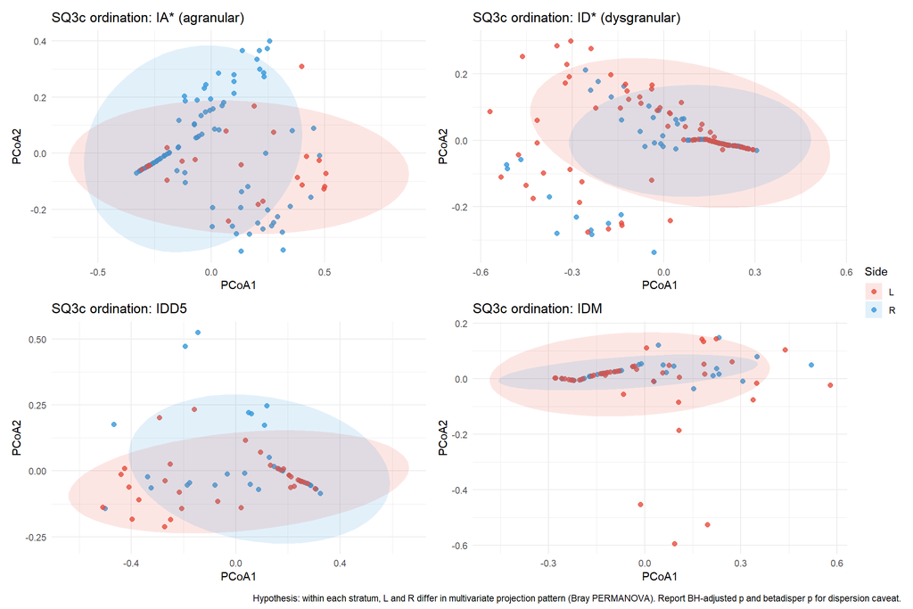

```r
# Simple ordination visual checks
plot_ord <- function(res, ttl) {
  if (is.null(res) || is.null(res$ord) || !nrow(res$ord)) return(NULL)
  ggplot(res$ord, aes(.data$Axis1, .data$Axis2, color = .data$Soma_Side)) +
    geom_point(size = 2.0, alpha = 0.8) +
    stat_ellipse(aes(fill = .data$Soma_Side), geom = "polygon", alpha = 0.14, color = NA) +
    scale_color_manual(values = c(L = "#E74C3C", R = "#3498DB")) +
    scale_fill_manual(values = c(L = "#E74C3C", R = "#3498DB")) +
    labs(title = ttl, x = "PCoA1", y = "PCoA2", color = "Side", fill = "Side") +
    theme_minimal(base_size = 11)
}

ord_plots <- list(
  plot_ord(class_results$agranular, "SQ3c ordination: IA* (agranular)"),
  plot_ord(class_results$dysgranular, "SQ3c ordination: ID* (dysgranular)"),
  plot_ord(target_results$IDD5, "SQ3c ordination: IDD5"),
  plot_ord(target_results$IDM, "SQ3c ordination: IDM")
)
ord_plots <- ord_plots[!vapply(ord_plots, is.null, logical(1))]
if (length(ord_plots)) {
  patchwork::wrap_plots(ord_plots, ncol = 2, guides = "collect") +
    plot_annotation(
      caption = "Hypothesis: within each stratum, L and R differ in multivariate projection pattern (Bray PERMANOVA). Report BH-adjusted p and betadisper p for dispersion caveat."
    )
}
```

```r
# Outcome report (auto-text)
sq3c_class_outcome <- if (nrow(class_tab)) {
  sprintf(
    "SQ3c outcome (IA/ID classes): %d/%d significant after BH; max side-imbalance ratio = %.2f.",
    sum(class_tab$significant, na.rm = TRUE),
    nrow(class_tab),
    max(class_tab$side_ratio, na.rm = TRUE)
  )
} else {
  "SQ3c outcome (IA/ID classes): insufficient strata for testing."
}
sq3c_target_outcome <- if (nrow(target_tab)) {
  sprintf(
    "SQ3c outcome (IDD5/IDM): %d/%d significant after BH; max side-imbalance ratio = %.2f.",
    sum(target_tab$significant, na.rm = TRUE),
    nrow(target_tab),
    max(target_tab$side_ratio, na.rm = TRUE)
  )
} else {
  "SQ3c outcome (IDD5/IDM): insufficient strata for testing."
}
cat("\n", sq3c_class_outcome, "\n", sq3c_target_outcome, "\n", sep = "")
```

```
##
## SQ3c outcome (IA/ID classes): 2/2 significant after BH; max side-imbalance ratio = 4.13.
## SQ3c outcome (IDD5/IDM): 0/2 significant after BH; max side-imbalance ratio = 1.38.
```

```r
save_plot(
  plot_obj = if (length(ord_plots)) patchwork::wrap_plots(ord_plots, ncol = 2, guides = "collect") else ggplot() + theme_void(),
  filename = "sq3c_region_stratified_multivariate.png",
  width = 12,
  height = 8
)
save_stats(class_tab, "sq3c_class_stratified_multivariate.csv")
save_stats(target_tab, "sq3c_targeted_multivariate.csv")

cleanup_vars(c("meta_sq3", "class_results", "class_tab", "target_results", "target_tab", "ord_plots"))
```

## SQ3d (v2): Projection laterality index by target brain region

Following prior single-neuron projectome work, this block summarizes **projection asymmetry** using a region-wise laterality index:

$$LI = \frac{\mu_L - \mu_R}{\mu_L + \mu_R
+ \epsilon}$$

where $\mu_L, \mu_R$ are mean ipsilateral projection strengths onto each target brain region from L/R neuron groups.

**Methodological definition (final endpoint):** - Endpoint in this notebook is **global hemispheric asymmetry** (L-source group vs R-source group), not within-neuron ipsi-vs-contra asymmetry. - Each neuron is first normalized to a **targeting-composition profile** (projection vector divided by that neuron’s total ipsi projection), then LI is computed from group means. - Inference is performed with region-wise Wilcoxon tests and **BH correction within each stratum family**; displayed stars and “significant” labels use BH q-values only. - This normalization emphasizes **relative targeting composition** and reduces dominance by high-output neurons, but correspondingly de-emphasizes absolute output magnitude differences.

```r
# SQ3d overview:
# - Laterality Index (LI) on projection-matrix targets with per-neuron proportion normalization.
# - LI is computed from group means of normalized profiles (less absolute-magnitude driven).
# - Reports BH-filtered region-level asymmetry and stratum-level LI distributions.
# Methodological note: per-neuron proportion normalization
# We normalize each neuron's target projection vector by its own total projection strength:
#   p_ij = x_ij / sum_k x_kj
# This converts absolute strengths into composition profiles (each neuron sums to 1),
# so downstream LI reflects relative targeting preference rather than total projection magnitude.
# Rationale: reduces dominance by high-output neurons and mitigates magnitude-driven shifts.
# Trade-off: absolute scale information is attenuated; interpret LI as pattern asymmetry.
eps_li <- 1e-8
region_names <- rownames(mat_ipsi)
mat_ipsi_prop_li <- mat_ipsi
tot_per_neuron_li <- colSums(mat_ipsi_prop_li, na.rm = TRUE)
ok_tot_li <- tot_per_neuron_li > 0
mat_ipsi_prop_li[, ok_tot_li] <- sweep(
  mat_ipsi_prop_li[, ok_tot_li, drop = FALSE],
  2,
  tot_per_neuron_li[ok_tot_li],
  "/"
)
meta_li <- meta[match(colnames(mat_ipsi), meta$NeuronID), , drop = FALSE] %>%
  mutate(Soma_Region_chr = trimws(as.character(Soma_Region)))

calc_li_table <- function(ids, stratum_name) {
  ids <- intersect(ids, colnames(mat_ipsi))
  if (length(ids) < 6L) return(NULL)

  sub_meta <- meta_li[match(ids, meta_li$NeuronID), , drop = FALSE]
  if (n_distinct(sub_meta$Soma_Side) < 2L) return(NULL)

  ids_L <- sub_meta$NeuronID[sub_meta$Soma_Side == "L"]
  ids_R <- sub_meta$NeuronID[sub_meta$Soma_Side == "R"]
  if (length(ids_L) < 3L || length(ids_R) < 3L) return(NULL)

  mean_L <- rowMeans(mat_ipsi_prop_li[, ids_L, drop = FALSE], na.rm = TRUE)
  mean_R <- rowMeans(mat_ipsi_prop_li[, ids_R, drop = FALSE], na.rm = TRUE)

  tab <- data.frame(
    stratum = stratum_name,
    target_region = region_names,
    mean_L = mean_L,
    mean_R = mean_R,
    n_L = length(ids_L),
    n_R = length(ids_R),
    LI = (mean_L - mean_R) / (mean_L + mean_R + eps_li),
    p_wilcox = vapply(region_names, function(rg) {
      x <- as.numeric(mat_ipsi_prop_li[rg, ids_L, drop = TRUE])
      y <- as.numeric(mat_ipsi_prop_li[rg, ids_R, drop = TRUE])
      tryCatch(
        suppressWarnings(wilcox.test(x, y, exact = FALSE)$p.value),
        error = function(e) NA_real_
      )
    }, numeric(1)),
    stringsAsFactors = FALSE
  ) %>%
    add_family_inference(p_col = "p_wilcox", family_id = paste0("sq3d_", stratum_name, "_targets"), adjust_method = "BH") %>%
    mutate(abs_LI = abs(.data$LI))
  tab
}

# Whole-brain stratum (all neurons)
li_all <- calc_li_table(meta_li$NeuronID, "all_neurons")

# Bilateral soma regions only
bilateral_soma_regions <- meta_li %>%
  filter(!is.na(Soma_Region_chr), nzchar(Soma_Region_chr)) %>%
  group_by(Soma_Region_chr) %>%
  filter(n_distinct(Soma_Side) == 2L) %>%
  group_keys() %>%
  pull(Soma_Region_chr)

li_region_list <- lapply(bilateral_soma_regions, function(reg) {
  ids <- meta_li$NeuronID[meta_li$Soma_Region_chr == reg]
  calc_li_table(ids, paste0("region_", reg))
})
li_region <- bind_rows(li_region_list)

li_all_tab <- bind_rows(li_all, li_region) %>%
  filter(!is.na(LI), is.finite(LI))

cat("SQ3d: LI summary (top |LI| per stratum)\n")
```

```
## SQ3d: LI summary (top |LI| per stratum)
```

```r
li_top <- li_all_tab %>%
  group_by(stratum) %>%
  slice_max(order_by = abs_LI, n = 5, with_ties = FALSE) %>%
  ungroup() %>%
  arrange(stratum, desc(abs_LI))
print(li_top)
```

```
## # A tibble: 20 × 17
##    stratum     target_region  mean_L  mean_R   n_L   n_R     LI p_wilcox   p_raw
##    <chr>       <chr>           <dbl>   <dbl> <int> <int>  <dbl>    <dbl>   <dbl>
##  1 all_neurons belt          0.0132  0         103   157  1.000 0.000405 4.05e-4
##  2 all_neurons STGc          0.00649 0         103   157  1.000 0.0132   1.32e-2
##  3 all_neurons ACC           0.00493 0         103   157  1.000 0.0322   3.22e-2
##  4 all_neurons VPons         0       0.00408   103   157 -1.000 0.104    1.04e-1
##  5 all_neurons LMid          0.00364 0         103   157  1.000 0.0322   3.22e-2
##  6 region_IAL  M1/PM         0       0.0670      7    95 -1.000 0.159    1.59e-1
##  7 region_IAL  LPal          0       0.0383      7    95 -1.000 0.229    2.29e-1
##  8 region_IAL  LMid          0.0234  0           7    95  1.000 0.000267 2.67e-4
##  9 region_IAL  PHy           0.0217  0           7    95  1.000 0.000267 2.67e-4
## 10 region_IAL  SII           0       0.0153      7    95 -1.000 0.506    5.06e-1
## 11 region_IDD5 STSf          0       0.0400     33    30 -1.000 0.0330   3.30e-2
## 12 region_IDD5 Rh            0       0.0341     33    30 -1.000 0.0330   3.30e-2
## 13 region_IDD5 TE            0       0.0248     33    30 -1.000 0.0330   3.30e-2
## 14 region_IDD5 caudal_OFC    0.0186  0          33    30  1.000 0.0527   5.27e-2
## 15 region_IDD5 ZI-H          0.0183  0          33    30  1.000 0.181    1.81e-1
## 16 region_IDM  belt          0.0214  0          44    32  1.000 0.0843   8.43e-2
## 17 region_IDM  vlPFC         0.0197  0          44    32  1.000 0.139    1.39e-1
## 18 region_IDM  area_7_in_IPL 0.0191  0          44    32  1.000 0.0843   8.43e-2
## 19 region_IDM  PThal         0.0178  0          44    32  1.000 0.139    1.39e-1
## 20 region_IDM  VThal         0.0140  0          44    32  1.000 0.139    1.39e-1
## # ℹ 8 more variables: p_adj <dbl>, adjust_method <chr>, family_id <chr>,
## #   significant <lgl>, sig_label <chr>, p_BH <dbl>, q_BH <dbl>, abs_LI <dbl>
```

```r
# Scientific stats table: BH-filtered significant targets with effect direction.
li_stats_table <- li_all_tab %>%
  mutate(
    direction = ifelse(LI >= 0, "L > R", "R > L"),
    receipt_class = case_when(
      mean_L > 0 & mean_R > 0 ~ "bilateral_receiving",
      TRUE ~ "one_side_only_or_extreme"
    )
  ) %>%
  filter(significant) %>%
  select(
    stratum, target_region, direction, LI, abs_LI,
    mean_L, mean_R, n_L, n_R, p_wilcox, p_BH, sig_label, receipt_class
  ) %>%
  arrange(stratum, desc(abs_LI))

cat("SQ3d: Significant LI targets (BH-filtered)\n")
```

```
## SQ3d: Significant LI targets (BH-filtered)
```

```r
if (nrow(li_stats_table)) {
  print(li_stats_table)
  cat("SQ3d: manuscript-style table (BH-significant rows)\n")
  print(
    knitr::kable(
      li_stats_table %>%
        mutate(
          LI = round(LI, 4),
          abs_LI = round(abs_LI, 4),
          mean_L = round(mean_L, 5),
          mean_R = round(mean_R, 5),
          p_wilcox = signif(p_wilcox, 3),
          p_BH = signif(p_BH, 3)
        ),
      caption = "SQ3d LI statistics (BH-significant targets; proportion-normalized endpoint)."
    )
  )
} else {
  cat("No BH-significant LI targets in current strata.\n")
}
```

```
##                   stratum target_region direction         LI    abs_LI
## belt          all_neurons          belt     L > R  0.9999992 0.9999992
## area_7_in_IPL all_neurons area_7_in_IPL     L > R  0.7115060 0.7115060
## M1/PM         all_neurons         M1/PM     R > L -0.6954372 0.6954372
## caudal_OFC    all_neurons    caudal_OFC     R > L -0.5187139 0.5187139
## LPal          all_neurons          LPal     L > R  0.3057289 0.3057289
## floor_of_ls   all_neurons   floor_of_ls     L > R  0.2192568 0.2192568
## LMid           region_IAL          LMid     L > R  0.9999996 0.9999996
## PHy            region_IAL           PHy     L > R  0.9999995 0.9999995
## HF             region_IAL            HF     L > R  0.9999985 0.9999985
##                    mean_L      mean_R n_L n_R     p_wilcox         p_BH
## belt          0.013150081 0.000000000 103 157 4.050085e-04 7.155151e-03
## area_7_in_IPL 0.020247539 0.003412951 103 157 4.710113e-03 4.160600e-02
## M1/PM         0.008103821 0.045112292 103 157 4.433946e-03 4.160600e-02
## caudal_OFC    0.116981258 0.369138134 103 157 5.367865e-09 2.844968e-07
## LPal          0.058414175 0.031059489 103 157 9.490501e-04 1.257491e-02
## floor_of_ls   0.517420329 0.331326751 103 157 5.299024e-05 1.404241e-03
## LMid          0.023399258 0.000000000   7  95 2.672217e-04 3.028513e-03
## PHy           0.021684613 0.000000000   7  95 2.672217e-04 3.028513e-03
## HF            0.006735158 0.000000000   7  95 2.672217e-04 3.028513e-03
##               sig_label            receipt_class
## belt                 ** one_side_only_or_extreme
## area_7_in_IPL         *      bilateral_receiving
## M1/PM                 *      bilateral_receiving
## caudal_OFC          ***      bilateral_receiving
## LPal                  *      bilateral_receiving
## floor_of_ls          **      bilateral_receiving
## LMid                 ** one_side_only_or_extreme
## PHy                  ** one_side_only_or_extreme
## HF                   ** one_side_only_or_extreme
## SQ3d: manuscript-style table (BH-significant rows)
##
##
## Table: SQ3d LI statistics (BH-significant targets; proportion-normalized endpoint).
##
## |              |stratum     |target_region |direction |      LI| abs_LI|  mean_L|  mean_R| n_L| n_R| p_wilcox|     p_BH|sig_label |receipt_class            |
## |:-------------|:-----------|:-------------|:---------|-------:|------:|-------:|-------:|---:|---:|--------:|--------:|:---------|:------------------------|
## |belt          |all_neurons |belt          |L > R     |  1.0000| 1.0000| 0.01315| 0.00000| 103| 157| 0.000405| 7.16e-03|**        |one_side_only_or_extreme |
## |area_7_in_IPL |all_neurons |area_7_in_IPL |L > R     |  0.7115| 0.7115| 0.02025| 0.00341| 103| 157| 0.004710| 4.16e-02|*         |bilateral_receiving      |
## |M1/PM         |all_neurons |M1/PM         |R > L     | -0.6954| 0.6954| 0.00810| 0.04511| 103| 157| 0.004430| 4.16e-02|*         |bilateral_receiving      |
## |caudal_OFC    |all_neurons |caudal_OFC    |R > L     | -0.5187| 0.5187| 0.11698| 0.36914| 103| 157| 0.000000| 3.00e-07|***       |bilateral_receiving      |
## |LPal          |all_neurons |LPal          |L > R     |  0.3057| 0.3057| 0.05841| 0.03106| 103| 157| 0.000949| 1.26e-02|*         |bilateral_receiving      |
## |floor_of_ls   |all_neurons |floor_of_ls   |L > R     |  0.2193| 0.2193| 0.51742| 0.33133| 103| 157| 0.000053| 1.40e-03|**        |bilateral_receiving      |
## |LMid          |region_IAL  |LMid          |L > R     |  1.0000| 1.0000| 0.02340| 0.00000|   7|  95| 0.000267| 3.03e-03|**        |one_side_only_or_extreme |
## |PHy           |region_IAL  |PHy           |L > R     |  1.0000| 1.0000| 0.02168| 0.00000|   7|  95| 0.000267| 3.03e-03|**        |one_side_only_or_extreme |
## |HF            |region_IAL  |HF            |L > R     |  1.0000| 1.0000| 0.00674| 0.00000|   7|  95| 0.000267| 3.03e-03|**        |one_side_only_or_extreme |
```

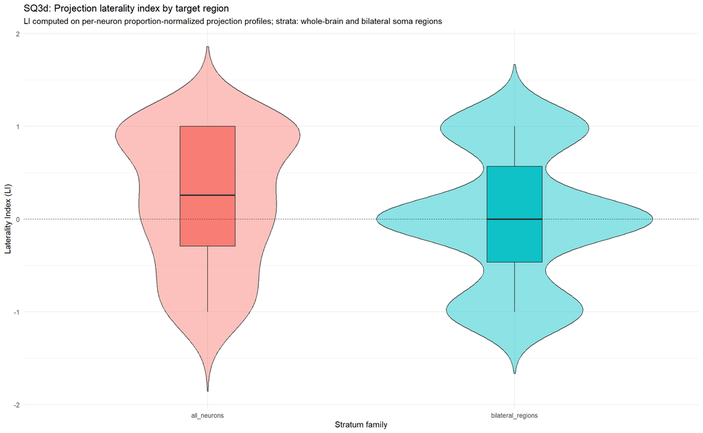

```r
# Compact visualization: LI distributions by stratum family
li_plot_df <- li_all_tab %>%
  mutate(
    stratum_family = case_when(
      stratum == "all_neurons" ~ "all_neurons",
      grepl("^region_", stratum) ~ "bilateral_regions",
      TRUE ~ "other"
    )
  )

ggplot(li_plot_df, aes(x = stratum_family, y = LI, fill = stratum_family)) +
  geom_violin(alpha = 0.45, trim = FALSE) +
  geom_boxplot(width = 0.18, outlier.size = 0.6, alpha = 0.9) +
  geom_hline(yintercept = 0, linetype = 2, linewidth = 0.35) +
  labs(
    title = "SQ3d: Projection laterality index by target region",
    subtitle = "LI computed on per-neuron proportion-normalized projection profiles; strata: whole-brain and bilateral soma regions",
    x = "Stratum family",
    y = "Laterality Index (LI)"
  ) +
  theme_minimal(base_size = 11) +
  theme(legend.position = "none")
```

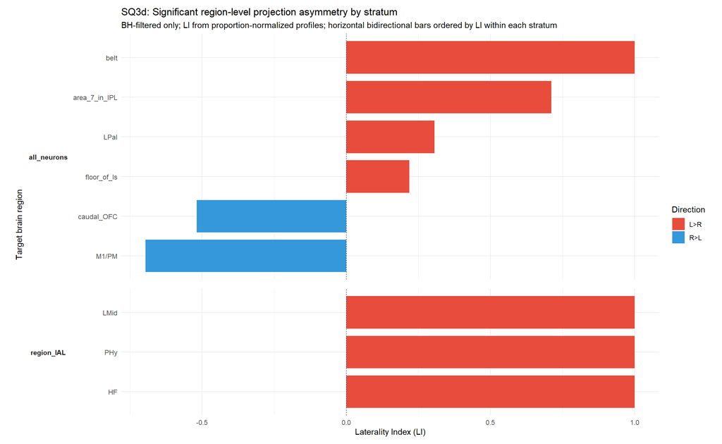

```r
# Region-level asymmetry bars (horizontal, bi-directional), ordered within stratum
li_bar_df <- li_all_tab %>%
  filter(significant) %>%
  filter(is.finite(LI), !is.na(target_region), !is.na(stratum)) %>%
  group_by(stratum) %>%
  arrange(LI, .by_group = TRUE) %>%
  mutate(
    target_region_stratum = paste0(stratum, "__", target_region),
    target_region_stratum = factor(target_region_stratum, levels = unique(target_region_stratum)),
    LI_dir = ifelse(LI >= 0, "L>R", "R>L")
  ) %>%
  ungroup()

if (nrow(li_bar_df)) {
  li_bar_plot <- ggplot(li_bar_df, aes(x = target_region_stratum, y = LI, fill = LI_dir)) +
    geom_col(width = 0.82) +
    geom_hline(yintercept = 0, linetype = 2, linewidth = 0.35) +
    coord_flip() +
    facet_grid(stratum ~ ., scales = "free_y", space = "free_y", switch = "y") +
    scale_x_discrete(labels = function(x) sub("^.*__", "", x)) +
    scale_fill_manual(values = c("L>R" = "#E74C3C", "R>L" = "#3498DB")) +
    labs(
      title = "SQ3d: Significant region-level projection asymmetry by stratum",
      subtitle = "BH-filtered only; LI from proportion-normalized profiles; horizontal bidirectional bars ordered by LI within each stratum",
      x = "Target brain region",
      y = "Laterality Index (LI)",
      fill = "Direction"
    ) +
    theme_minimal(base_size = 11) +
    theme(
      strip.text.y.left = element_text(face = "bold", angle = 0),
      axis.text.y = element_text(size = 9),
      panel.spacing.y = unit(0.8, "lines"),
      strip.placement = "outside",
      plot.margin = margin(10, 16, 10, 20)
    )
} else {
  li_bar_plot <- ggplot() +
    annotate("text", x = 0, y = 0, label = "No BH-significant LI regions in current strata") +
    theme_void() +
    labs(title = "SQ3d: Significant region-level projection asymmetry by stratum")
}

print(li_bar_plot)
```

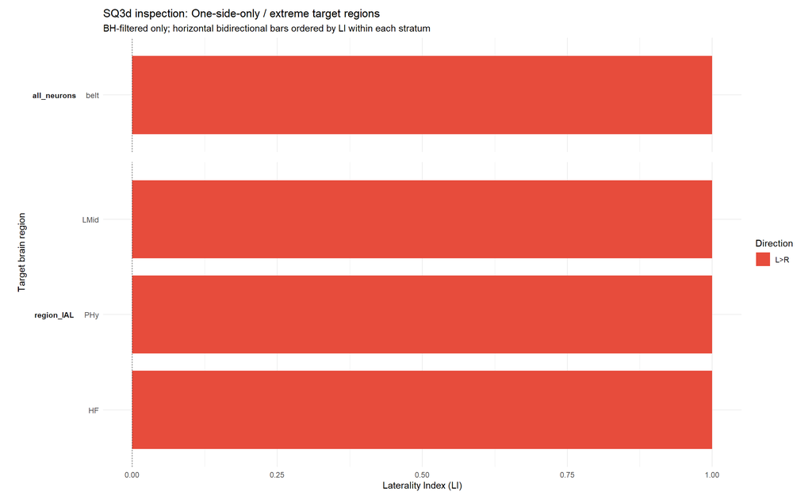

```r
save_plot(
  plot_obj = li_bar_plot,
  filename = "sq3d_projection_laterality_index_bars.png",
  width = 16,
  height = 14
)

# Inspection split: one-sided/extreme targets vs bilateral-receiving targets
li_inspect_df <- li_all_tab %>%
  filter(significant) %>%
  filter(is.finite(LI), !is.na(target_region), !is.na(stratum)) %>%
  mutate(
    receipt_class = case_when(
      mean_L > 0 & mean_R > 0 ~ "bilateral_receiving",
      TRUE ~ "one_side_only_or_extreme"
    )
  )

make_li_inspect_plot <- function(df, title_txt) {
  if (!nrow(df)) {
    return(
      ggplot() +
        annotate("text", x = 0, y = 0, label = "No regions available in this class") +
        theme_void() +
        labs(title = title_txt)
    )
  }

  df2 <- df %>%
    group_by(.data$stratum) %>%
    arrange(.data$LI, .by_group = TRUE) %>%
    mutate(
      target_region_stratum = paste0(.data$stratum, "__", .data$target_region),
      target_region_stratum = factor(.data$target_region_stratum, levels = unique(.data$target_region_stratum)),
      LI_dir = ifelse(.data$LI >= 0, "L>R", "R>L")
    ) %>%
    ungroup()

  ggplot(df2, aes(x = .data$target_region_stratum, y = .data$LI, fill = .data$LI_dir)) +
    geom_col(width = 0.82) +
    geom_hline(yintercept = 0, linetype = 2, linewidth = 0.35) +
    coord_flip() +
    facet_grid(stratum ~ ., scales = "free_y", space = "free_y", switch = "y") +
    scale_x_discrete(labels = function(x) sub("^.*__", "", x)) +
    scale_fill_manual(values = c("L>R" = "#E74C3C", "R>L" = "#3498DB")) +
    labs(
      title = title_txt,
      subtitle = "BH-filtered only; horizontal bidirectional bars ordered by LI within each stratum",
      x = "Target brain region",
      y = "Laterality Index (LI)",
      fill = "Direction"
    ) +
    theme_minimal(base_size = 11) +
    theme(
      strip.text.y.left = element_text(face = "bold", angle = 0),
      axis.text.y = element_text(size = 9),
      panel.spacing.y = unit(0.8, "lines"),
      strip.placement = "outside",
      plot.margin = margin(10, 16, 10, 20)
    )
}

li_one_side_plot <- make_li_inspect_plot(
  li_inspect_df %>% filter(receipt_class == "one_side_only_or_extreme"),
  "SQ3d inspection: One-side-only / extreme target regions"
)
print(li_one_side_plot)
```

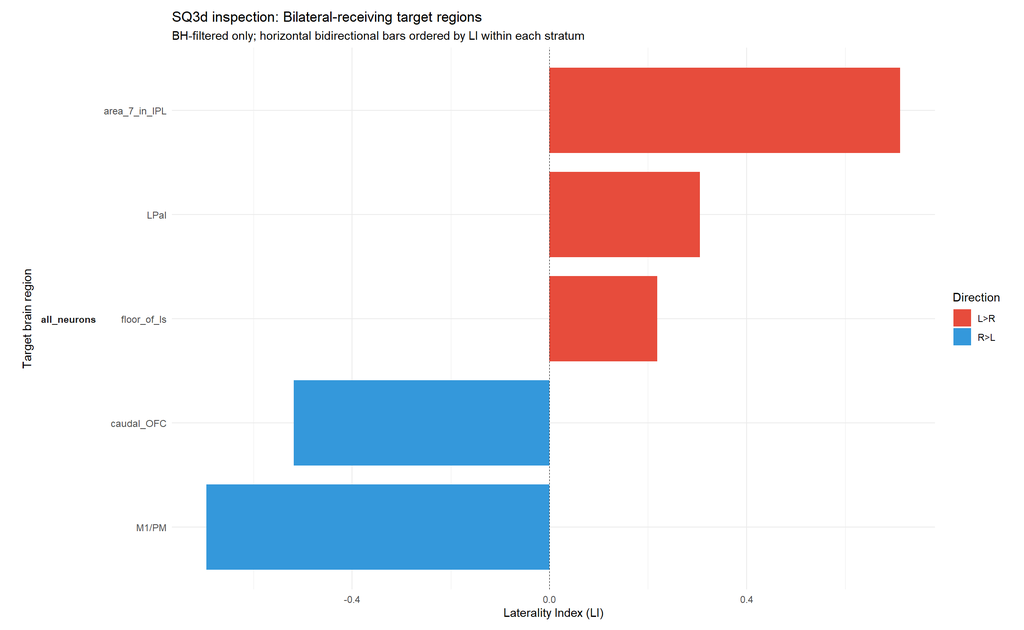

```r
save_plot(
  plot_obj = li_one_side_plot,
  filename = "sq3d_li_inspect_one_side_or_extreme.png",
  width = 16,
  height = 12
)

li_bilateral_plot <- make_li_inspect_plot(
  li_inspect_df %>% filter(receipt_class == "bilateral_receiving"),
  "SQ3d inspection: Bilateral-receiving target regions"
)
print(li_bilateral_plot)
```

```r
save_plot(
  plot_obj = li_bilateral_plot,
  filename = "sq3d_li_inspect_bilateral_receiving.png",
  width = 16,
  height = 12
)

save_plot(
  plot_obj = ggplot(li_plot_df, aes(x = stratum_family, y = LI, fill = stratum_family)) +
    geom_violin(alpha = 0.45, trim = FALSE) +
    geom_boxplot(width = 0.18, outlier.size = 0.6, alpha = 0.9) +
    geom_hline(yintercept = 0, linetype = 2, linewidth = 0.35) +
    labs(
      title = "SQ3d: Projection laterality index by target region",
      subtitle = "LI computed on per-neuron proportion-normalized projection profiles; strata: whole-brain and bilateral soma regions",
      x = "Stratum family",
      y = "Laterality Index (LI)"
    ) +
    theme_minimal(base_size = 11) +
    theme(legend.position = "none"),
  filename = "sq3d_projection_laterality_index.png",
  width = 11,
  height = 6.5
)
save_table(li_all_tab, "sq3d_li_all_targets.csv")
save_table(li_top, "sq3d_li_top_abs_by_stratum.csv")
if (nrow(li_stats_table)) save_stats(li_stats_table, "sq3d_li_significant_bh.csv")
if (nrow(li_bar_df)) save_table(li_bar_df, "sq3d_li_barplot_source.csv")

cleanup_vars(c(
  "meta_li", "region_names", "li_all", "bilateral_soma_regions",
  "li_region_list", "li_region", "li_all_tab", "li_top", "li_plot_df", "li_stats_table",
  "li_bar_df", "li_bar_plot", "li_inspect_df", "li_one_side_plot", "li_bilateral_plot",
  "make_li_inspect_plot",
  "eps_li", "mat_ipsi_prop_li", "tot_per_neuron_li", "ok_tot_li"
))
```

## SQ3e (new): Gou-style per-neuron hemispheric bias index

This block keeps your SQ3d region-level endpoint unchanged, and adds a Gou-style **per-neuron** asymmetry endpoint:

$$LI_j = \frac{contra_j - ipsi_j}{contra_j
+ ipsi_j + \epsilon}$$

where `ipsi_j` and `contra_j` are neuron-level total projection strengths.

**Current-data clarification (important):** in this dataset, if we apply a strict bilateral-projection criterion (`ipsi_j > 0` and `contra_j > 0`), the usable neuron count is very small (about 6). Therefore SQ3e is treated as **descriptive / exploratory** here; inferential p-values are only reported when both sides have minimally usable sample size.

```r
eps_li_n <- 1e-8
MIN_N_PER_SIDE_SQ3E <- 3L

ipsi_total <- colSums(mat_ipsi, na.rm = TRUE)
contra_total <- colSums(mat_contra, na.rm = TRUE)

li_neuron_df <- meta %>%
  mutate(
    ipsi_total = ipsi_total[match(NeuronID, names(ipsi_total))],
    contra_total = contra_total[match(NeuronID, names(contra_total))]
  ) %>%
  mutate(
    LI_neuron = (contra_total - ipsi_total) / (contra_total + ipsi_total + eps_li_n),
    valid_total = is.finite(LI_neuron) & is.finite(ipsi_total) & is.finite(contra_total),
    bilateral_proj = (ipsi_total > 0) & (contra_total > 0)
  )

cat(sprintf("SQ3e data source: %s\n", PATH_INS_XLSX))
```

```
## SQ3e data source: ../../neuron_tables_new/251637_INS_HE_inferred.xlsx
```

```r
cat(sprintf("SQ3e: all neurons in meta = %d\n", nrow(meta)))
```

```
## SQ3e: all neurons in meta = 260
```

```r
cat(sprintf("SQ3e: valid LI neurons (finite totals) = %d\n", sum(li_neuron_df$valid_total, na.rm = TRUE)))
```

```
## SQ3e: valid LI neurons (finite totals) = 260
```

```r
cat(sprintf("SQ3e: bilateral-projecting neurons (all types) = %d\n", sum(li_neuron_df$valid_total & li_neuron_df$bilateral_proj, na.rm = TRUE)))
```

```
## SQ3e: bilateral-projecting neurons (all types) = 6
```

```r
cat(sprintf("SQ3e: bilateral-projecting ITc neurons = %d\n", sum(li_neuron_df$valid_total & li_neuron_df$bilateral_proj & li_neuron_df$Neuron_Type == "ITc", na.rm = TRUE)))
```

```
## SQ3e: bilateral-projecting ITc neurons = 3
```

```r
li_neuron_df <- li_neuron_df %>%
  filter(valid_total, bilateral_proj)

cat(sprintf("SQ3e: valid bilateral-projecting neurons for per-neuron LI = %d\n", nrow(li_neuron_df)))
```

```
## SQ3e: valid bilateral-projecting neurons for per-neuron LI = 6
```

```r
cat("SQ3e: side counts among bilateral-projecting neurons\n")
```

```
## SQ3e: side counts among bilateral-projecting neurons
```

```r
print(li_neuron_df %>% count(Soma_Side, name = "n"))
```

```
##   Soma_Side n
## 1         L 1
## 2         R 5
```

```r
# Overall L vs R comparison (same side label as in current notebook: source Soma_Side)
sq3e_overall <- li_neuron_df %>%
  group_by(Soma_Side) %>%
  summarise(
    n = n(),
    median_LI = median(LI_neuron, na.rm = TRUE),
    mean_LI = mean(LI_neuron, na.rm = TRUE),
    .groups = "drop"
  )

enough_for_overall_test <- (
  n_distinct(li_neuron_df$Soma_Side) == 2L &&
  sum(li_neuron_df$Soma_Side == "L") >= MIN_N_PER_SIDE_SQ3E &&
  sum(li_neuron_df$Soma_Side == "R") >= MIN_N_PER_SIDE_SQ3E
)

if (!enough_for_overall_test) {
  message(
    "SQ3e: bilateral-projection sample is too small/imbalanced for stable L vs R inference; ",
    "report LI descriptively only (set p-values to NA)."
  )
}

sq3e_overall_test <- if (enough_for_overall_test) {
  p <- tryCatch(
    suppressWarnings(wilcox.test(LI_neuron ~ Soma_Side, data = li_neuron_df, exact = FALSE)$p.value),
    error = function(e) NA_real_
  )
  data.frame(
    stratum = "all_neurons",
    p_mwu = p,
    p_raw = p,
    n_L = sum(li_neuron_df$Soma_Side == "L"),
    n_R = sum(li_neuron_df$Soma_Side == "R"),
    stringsAsFactors = FALSE
  ) %>% add_family_inference(p_col = "p_raw", family_id = "sq3e_all_neurons", adjust_method = "none")
} else {
  data.frame(
    stratum = "all_neurons",
    p_mwu = NA_real_,
    p_raw = NA_real_,
    n_L = sum(li_neuron_df$Soma_Side == "L"),
    n_R = sum(li_neuron_df$Soma_Side == "R"),
    stringsAsFactors = FALSE
  ) %>% add_family_inference(p_col = "p_raw", family_id = "sq3e_all_neurons", adjust_method = "none")
}

# Type-stratified Gou-style tests
sq3e_type_test <- li_neuron_df %>%
  group_by(Neuron_Type) %>%
  filter(
    n_distinct(Soma_Side) == 2L,
    sum(Soma_Side == "L") >= MIN_N_PER_SIDE_SQ3E,
    sum(Soma_Side == "R") >= MIN_N_PER_SIDE_SQ3E
  ) %>%
  summarise(
    n = n(),
    n_L = sum(Soma_Side == "L"),
    n_R = sum(Soma_Side == "R"),
    median_L = median(LI_neuron[Soma_Side == "L"], na.rm = TRUE),
    median_R = median(LI_neuron[Soma_Side == "R"], na.rm = TRUE),
    p_mwu = tryCatch(
      suppressWarnings(wilcox.test(LI_neuron ~ Soma_Side, exact = FALSE)$p.value),
      error = function(e) NA_real_
    ),
    .groups = "drop"
  ) %>%
  add_family_inference(p_col = "p_mwu", family_id = "sq3e_type_stratified", adjust_method = "BH") %>%
  arrange(p_adj, desc(abs(median_L - median_R)))

cat("SQ3e: Overall per-neuron LI summary\n")
```

```
## SQ3e: Overall per-neuron LI summary
```

```r
print(sq3e_overall)
```

```
## # A tibble: 2 × 4
##   Soma_Side     n median_LI mean_LI
##   <fct>     <int>     <dbl>   <dbl>
## 1 L             1    -0.102  -0.102
## 2 R             5    -0.459  -0.485
```

```r
cat("SQ3e: Overall L vs R Mann-Whitney\n")
```

```
## SQ3e: Overall L vs R Mann-Whitney
```

```r
print(sq3e_overall_test)
```

```
##       stratum p_mwu p_raw n_L n_R p_adj adjust_method        family_id
## 1 all_neurons    NA    NA   1   5    NA          none sq3e_all_neurons
##   significant sig_label p_BH q_BH
## 1          NA      <NA>   NA   NA
```

```r
cat("SQ3e: Type-stratified per-neuron LI Mann-Whitney (BH)\n")
```

```
## SQ3e: Type-stratified per-neuron LI Mann-Whitney (BH)
```

```r
print(sq3e_type_test)
```

```
##  [1] Neuron_Type   n             n_L           n_R           median_L
##  [6] median_R      p_mwu         p_raw         p_adj         adjust_method
## [11] family_id     significant   sig_label     p_BH          q_BH
## <0 rows> (or 0-length row.names)
```

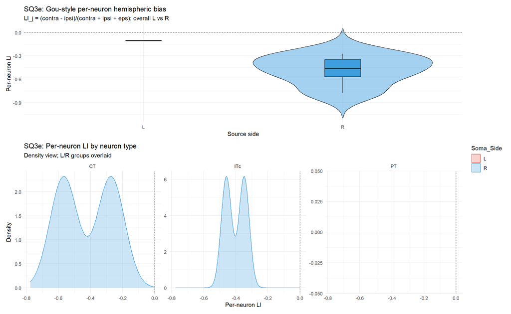

```r
# Visualization
sq3e_p1 <- ggplot(li_neuron_df, aes(x = Soma_Side, y = LI_neuron, fill = Soma_Side)) +
  geom_violin(trim = FALSE, alpha = 0.45, width = 0.9) +
  geom_boxplot(width = 0.18, outlier.size = 0.5, alpha = 0.9) +
  geom_hline(yintercept = 0, linetype = 2, linewidth = 0.35) +
  scale_fill_manual(values = c(L = "#E74C3C", R = "#3498DB")) +
  labs(
    title = "SQ3e: Gou-style per-neuron hemispheric bias",
    subtitle = "LI_j = (contra - ipsi)/(contra + ipsi + eps); overall L vs R",
    x = "Source side",
    y = "Per-neuron LI"
  ) +
  theme_minimal(base_size = 11) +
  theme(legend.position = "none")

sq3e_p2 <- ggplot(li_neuron_df, aes(x = LI_neuron, color = Soma_Side, fill = Soma_Side)) +
  geom_density(alpha = 0.25, linewidth = 0.5) +
  facet_wrap(~Neuron_Type, scales = "free_y") +
  geom_vline(xintercept = 0, linetype = 2, linewidth = 0.35) +
  scale_color_manual(values = c(L = "#E74C3C", R = "#3498DB")) +
  scale_fill_manual(values = c(L = "#E74C3C", R = "#3498DB")) +
  labs(
    title = "SQ3e: Per-neuron LI by neuron type",
    subtitle = "Density view; L/R groups overlaid",
    x = "Per-neuron LI",
    y = "Density"
  ) +
  theme_minimal(base_size = 11)

sq3e_fig <- (sq3e_p1 / sq3e_p2) +
  plot_layout(heights = c(1, 1.25), guides = "collect")
print(sq3e_fig)
```

```r
save_plot(sq3e_fig, "sq3e_per_neuron_li.png", width = 13, height = 9.5)
# Exports
save_table(li_neuron_df, "sq3e_per_neuron_li_values.csv")
save_stats(sq3e_overall, "sq3e_overall_li_summary.csv")
save_stats(sq3e_overall_test, "sq3e_overall_li_mwu.csv")
save_stats(sq3e_type_test, "sq3e_type_stratified_li_mwu.csv")

cleanup_vars(c(
  "eps_li_n", "ipsi_total", "contra_total", "li_neuron_df",
  "MIN_N_PER_SIDE_SQ3E", "enough_for_overall_test",
  "sq3e_overall", "sq3e_overall_test", "sq3e_type_test",
  "sq3e_p1", "sq3e_p2", "sq3e_fig"
))
```

## SQ4: Are **pairwise FNT distances** concordant with **pairwise projection distances**?

**Hypothesis**: Pairs closer in morphology tend to be closer in projection space (direction and strength of association are empirical).  
**Method**: On `common_ids`, **Mantel test** correlates the two distance matrices with a permutation null (proper inference for matrix-valued dependence). A raw **Spearman correlation** on upper-triangle pairs duplicates entries and **does not yield a valid independent-sample p-value**; we still report **rho** descriptively and use **Mantel’s permuted p** for significance.  
Projection distance here is Bray-Curtis on **per-neuron proportion-normalized** profiles (pattern-focused endpoint).

```r
ut <- upper.tri(fnt_sub)
# Visualization-only min-max normalization of FNT distance to [0,1]
# (Mantel inference remains on raw fnt_sub distance matrix).
fnt01 <- fnt_sub
fnt_lo <- min(fnt_sub[ut], na.rm = TRUE)
fnt_hi <- max(fnt_sub[ut], na.rm = TRUE)
if (is.finite(fnt_lo) && is.finite(fnt_hi) && fnt_hi > fnt_lo) {
  fnt01[ut] <- (fnt_sub[ut] - fnt_lo) / (fnt_hi - fnt_lo)
  fnt01[lower.tri(fnt01)] <- t(fnt01)[lower.tri(fnt01)]
} else {
  fnt01[ut] <- 0
  fnt01[lower.tri(fnt01)] <- 0
}
diag(fnt01) <- 0

fv <- fnt01[ut]
pv <- proj_dist[ut]

# Descriptive association only — pairs are not independent; do not interpret cor.test p-value
sp_rho <- suppressWarnings(cor(fv, pv, method = "spearman", use = "complete.obs"))
cat(sprintf("Spearman rho (upper triangle, descriptive) = %.3f\n", sp_rho))
```

```
## Spearman rho (upper triangle, descriptive) = 0.360
```

```r
mt <- mantel(as.dist(fnt_sub), as.dist(proj_dist), method = "spearman", permutations = PERM_N)
print(mt)
```

```
##
## Mantel statistic based on Spearman's rank correlation rho
##
## Call:
## mantel(xdis = as.dist(fnt_sub), ydis = as.dist(proj_dist), method = "spearman",      permutations = PERM_N)
##
## Mantel statistic r: 0.3603
##       Significance: 0.001
##
## Upper quantiles of permutations (null model):
##    90%    95%  97.5%    99%
## 0.0259 0.0334 0.0381 0.0461
## Permutation: free
## Number of permutations: 999
```

```r
sq4_summary <- data.frame(
  statistic = unname(mt$statistic),
  p = unname(mt$signif)
) %>%
  add_family_inference(p_col = "p", family_id = "sq4_single_mantel", adjust_method = "none")
print(sq4_summary)
```

```
##   statistic     p p_raw p_adj adjust_method         family_id significant
## 1 0.3603229 0.001 0.001 0.001          none sq4_single_mantel        TRUE
##   sig_label p_BH q_BH
## 1        **   NA   NA
```

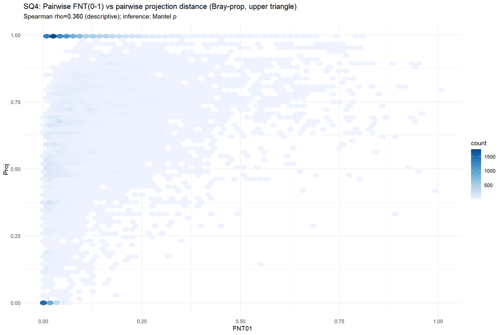

```r
save_stats(sq4_summary, "sq4_mantel_summary.csv")

ggplot(data.frame(FNT01 = fv, Proj = pv), aes(FNT01, Proj)) +
  geom_hex(bins = 60) +
  scale_fill_distiller(palette = "Blues", direction = 1) +
  labs(title = "SQ4: Pairwise FNT(0-1) vs pairwise projection distance (Bray-prop, upper triangle)",
       subtitle = sprintf("Spearman rho=%.3f (descriptive); inference: Mantel p", sp_rho)) +
  theme_minimal()
```

## SQ5: How to compare the two distance matrices side by side in heatmaps?

**Key idea**: Both heatmaps must use the **same row/column order** (here from a fused clustering signal). A third panel shows **|**$\Delta rank$| per pair to show rank-order disagreement between `FNT01` and projection distances (robust for sparse, non-parametric data).  
`Proj` is the SQ4/SQ5 endpoint: Bray-Curtis on per-neuron proportion-normalized profiles.

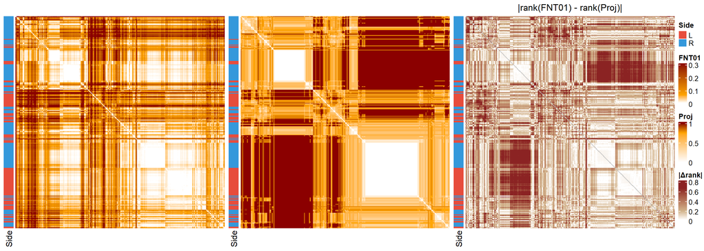

```r
ut_h <- upper.tri(fnt_sub)
side_lab <- meta_fnt$Soma_Side[match(rownames(fnt_sub), meta_fnt$NeuronID)]
ha <- rowAnnotation(
  Side = side_lab,
  col = list(Side = c(L = "#E74C3C", R = "#3498DB"))
)

# Visualization-only min-max normalization of FNT to [0,1]
fnt01_h <- fnt_sub
fnt_h_lo <- min(fnt_sub[ut_h], na.rm = TRUE)
fnt_h_hi <- max(fnt_sub[ut_h], na.rm = TRUE)
if (is.finite(fnt_h_lo) && is.finite(fnt_h_hi) && fnt_h_hi > fnt_h_lo) {
  fnt01_h[ut_h] <- (fnt_sub[ut_h] - fnt_h_lo) / (fnt_h_hi - fnt_h_lo)
  fnt01_h[lower.tri(fnt01_h)] <- t(fnt01_h)[lower.tri(fnt01_h)]
} else {
  fnt01_h[ut_h] <- 0
  fnt01_h[lower.tri(fnt01_h)] <- 0
}
diag(fnt01_h) <- 0

# Rank-based mismatch (robust to scale and tail differences):
# compare relative pair ordering between FNT and projection distances.
f_vals <- fnt01_h[ut_h]
p_vals <- proj_dist[ut_h]
f_rank01 <- (rank(f_vals, ties.method = "average") - 1) / (length(f_vals) - 1)
p_rank01 <- (rank(p_vals, ties.method = "average") - 1) / (length(p_vals) - 1)
diff_rank <- abs(f_rank01 - p_rank01)

rank_mismatch <- matrix(NA_real_, nrow = nrow(fnt01_h), ncol = ncol(fnt01_h),
                        dimnames = dimnames(fnt01_h))
rank_mismatch[ut_h] <- diff_rank
rank_mismatch[lower.tri(rank_mismatch)] <- t(rank_mismatch)[lower.tri(rank_mismatch)]
diag(rank_mismatch) <- NA

combo <- (fnt01_h + proj_dist / max(proj_dist)) / 2
ord <- hclust(as.dist(combo))$order

rcols <- function(x, utm) {
  colorRamp2(quantile(x[utm], c(0.05, 0.5, 0.95)), c("white", "orange", "red4"))
}

Heatmap(fnt01_h, name = "FNT01", col = rcols(fnt01_h, ut_h),
        left_annotation = ha, cluster_rows = FALSE, cluster_columns = FALSE,
        row_order = ord, column_order = ord, show_row_names = FALSE, show_column_names = FALSE) +
Heatmap(proj_dist, name = "Proj", col = rcols(proj_dist, ut_h),
        left_annotation = ha, cluster_rows = FALSE, cluster_columns = FALSE,
        row_order = ord, column_order = ord, show_row_names = FALSE, show_column_names = FALSE) +
Heatmap(rank_mismatch, name = "|Δrank|",
        col = colorRamp2(quantile(rank_mismatch, c(0.05, 0.5, 0.95), na.rm = TRUE), c("white", "tan", "brown4")),
        left_annotation = ha, cluster_rows = FALSE, cluster_columns = FALSE,
        row_order = ord, column_order = ord, show_row_names = FALSE, show_column_names = FALSE,
        column_title = "|rank(FNT01) - rank(Proj)|")
```

## SQ6 removed in hybrid script

SQ6 (type-stratified PERMANOVA) is intentionally removed here because it is not meaningful under the current small and imbalanced sample regime. Interpretation should rely on SQ3/SQ3c (multivariate pattern) and SQ3d/SQ3e (LI summaries with explicit small-n caveats).

# Export results

Interactive mode: final workbook export chunk removed to keep this notebook focused on chunk-by-chunk analysis and debugging.

```r
# Consolidated export: one workbook per SQ (multi-sheet).
write_sq_reports()
```